# Supplemental Code for Verhoeven et al.

Mike Verhoeven

2019-12-30

This code will load in the MN CLP dataset and analyze and visualize the material presented in Verhoeven et al. 2019. Additonal dataset assembly and processing code are available upon request from the authors.

```r
# header ------------------------------------------------------------------
```

# Tools

Load libraries:

```r
  #+warning=FALSE, message=FALSE
  library(ggplot2)
  library(lme4)
  library(dplyr)
  library(data.table)
  library(numDeriv)
  library(sf)
  library(mapdata)
  library(gridExtra)
  library(rlang)
  library(devtools)
  devtools::install_github('oswaldosantos/ggsn')
  library(ggsn)
  library(raster)
  library(ggthemes)
  library(mapproj)
  library(maps)
  library(GISTools)
  library(ggmap)
  #' Load custom functions:

  # diagnostics
  mv_diag <- function(model_to_diag, plots = c(1:4)) {
    par(mfrow = c(2,2))
    plot(model_to_diag, which = plots)
    par(mfrow = c(1,1))
  }

    # ben bolkers CI calc fn (https://github.com/bbolker/asaglmm/blob/master/papers/bolker_chap.rmd)
  easyPredCI <- function(model,newdata,alpha=0.05) {
    ## baseline prediction, on the linear predictor (log-odds) scale:
    pred0 <- predict(model,re.form=NA,newdata=newdata)
    ## fixed-effects model matrix for new data
    X <- model.matrix(formula(model,fixed.only=TRUE)[-2],
                      newdata)
    beta <- fixef(model) ## fixed-effects coefficients
    V <- vcov(model)     ## variance-covariance matrix of beta
    pred.se <- sqrt(diag(X %*% V %*% t(X))) ## std errors of predictions
    ## inverse-link (logistic) function: could also use plogis()
    plogis <- model@resp$family$plogis
    ## construct 95% Normal CIs on the link scale and
    ##  transform back to the response (probability) scale:
    crit <- -qnorm(alpha/2)
    plogis(cbind(lwr=pred0-crit*pred.se,
                 upr=pred0+crit*pred.se))
  }

# load in data ------------------------------------------------------------
```

# Load Data

Load in clp dataset from the p_crispus dataset_prep script:

```r
  pcri.e <- fread("data/output_data/pcri.e_akDNRmv_combined.csv", drop = 1:2)
  pcri.p <- fread("data/output_data/pcri.p_akDNRmv_combined.csv", drop = 1:2)
```

Visualize the distributions of the responses we are interested in:

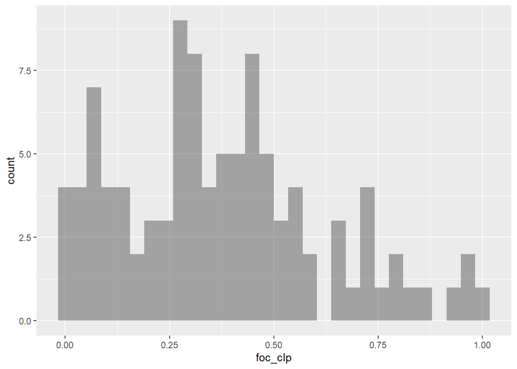

```r
  #foc: shown with my calcs(gray) and Adam's calcs (red)
  ggplot(pcri.e, aes(foc_clp))+
      geom_histogram(alpha = .5)
```

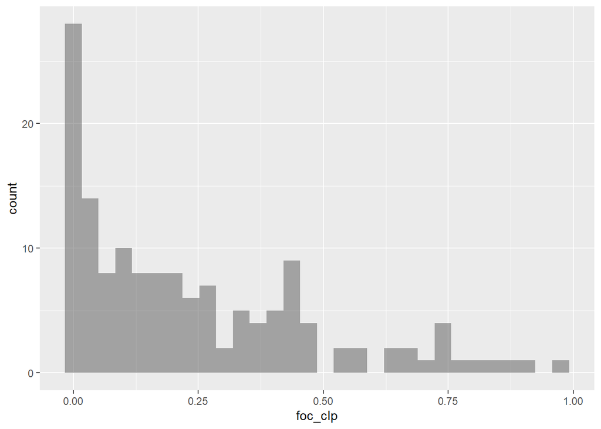

```r
  ggplot(pcri.p, aes(foc_clp))+
      geom_histogram(alpha = .5)
```

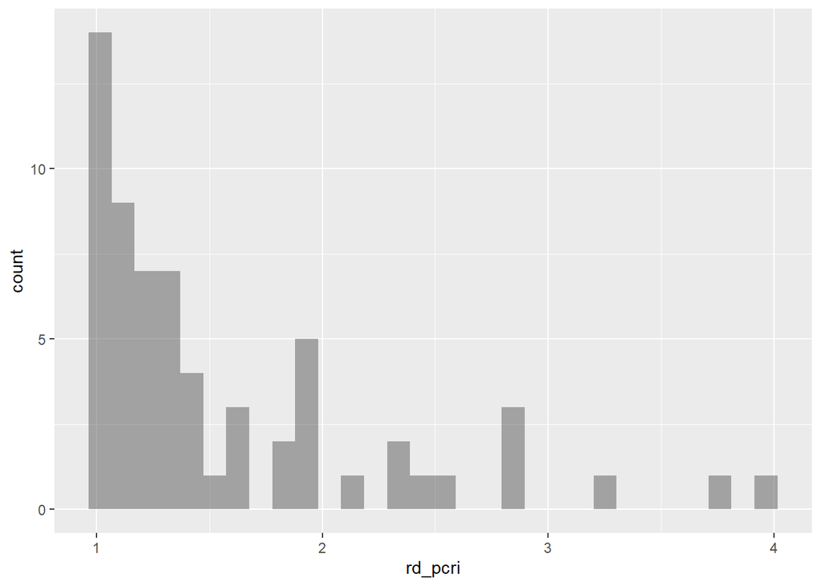

```r
  #rake density
  ggplot(pcri.e, aes(rd_pcri))+
      geom_histogram(alpha = .5 )
```

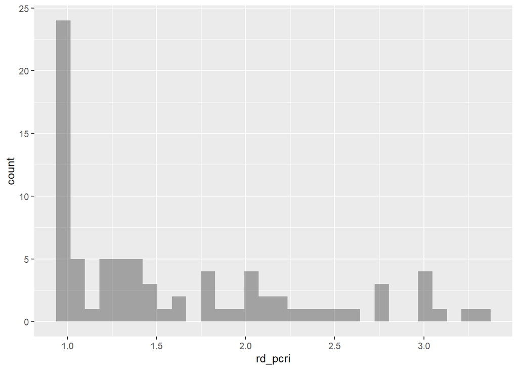

```r
  ggplot(pcri.p, aes(rd_pcri))+
      geom_histogram(alpha = .5)
```

```r
# cleaning data -----------------------------------------------------------
```

# Data Cleaning

Are our datasets complete for the parameters we want to estimate on? Note that the rake densities will be pres for a smaller proportion of the data (see descriptive stats for these values).

```r
  #check 6 num summaries
  summary(pcri.e[,c("foc_clp","rd_pcri","nsamp","perc.cheme","cytrt","Snow","IceCover","PrevAUGSecchi")])
```

```
##     foc_clp          rd_pcri          nsamp         perc.cheme
##  Min.   :0.0000   Min.   :1.000   Min.   :  8.0   Min.   :0.0000
##  1st Qu.:0.2083   1st Qu.:1.087   1st Qu.:106.0   1st Qu.:0.0000
##  Median :0.3431   Median :1.286   Median :126.0   Median :0.0000
##  Mean   :0.3760   Mean   :1.562   Mean   :149.4   Mean   :0.2970
##  3rd Qu.:0.5209   3rd Qu.:1.884   3rd Qu.:165.0   3rd Qu.:0.3777
##  Max.   :1.0000   Max.   :3.947   Max.   :430.0   Max.   :2.2932
##                   NA's   :38
##      cytrt             Snow          IceCover     PrevAUGSecchi
##  Min.   :0.0000   Min.   : 1.50   Min.   :104.0   Min.   :0.200
##  1st Qu.:0.0000   1st Qu.: 6.20   1st Qu.:122.0   1st Qu.:0.600
##  Median :0.0000   Median :11.50   Median :137.0   Median :0.800
##  Mean   :0.5545   Mean   :13.25   Mean   :133.4   Mean   :1.063
##  3rd Qu.:1.0000   3rd Qu.:19.70   3rd Qu.:143.0   3rd Qu.:1.400
##  Max.   :5.0000   Max.   :39.20   Max.   :162.0   Max.   :3.500
##
```

```r
  summary(pcri.p[,c("foc_clp","rd_pcri","nsamp","perc.lit.chem","cytrt","Snow","IceCover","PrevAUGSecchi")])
```

```
##     foc_clp           rd_pcri          nsamp       perc.lit.chem
##  Min.   :0.00000   Min.   :1.000   Min.   :  5.0   Min.   :0.0000
##  1st Qu.:0.02878   1st Qu.:1.000   1st Qu.: 91.0   1st Qu.:0.0000
##  Median :0.17000   Median :1.359   Median :119.0   Median :0.0000
##  Mean   :0.23823   Mean   :1.614   Mean   :143.8   Mean   :0.2589
##  3rd Qu.:0.39640   3rd Qu.:2.033   3rd Qu.:156.0   3rd Qu.:0.3219
##  Max.   :0.97479   Max.   :3.358   Max.   :653.0   Max.   :2.2932
##                    NA's   :65
##      cytrt             Snow         IceCover   PrevAUGSecchi
##  Min.   :0.0000   Min.   : 1.1   Min.   :103   Min.   :0.200
##  1st Qu.:0.0000   1st Qu.: 6.2   1st Qu.:124   1st Qu.:0.500
##  Median :0.0000   Median :12.6   Median :137   Median :0.800
##  Mean   :0.6345   Mean   :14.2   Mean   :134   Mean   :1.181
##  3rd Qu.:1.0000   3rd Qu.:22.6   3rd Qu.:143   3rd Qu.:1.400
##  Max.   :8.0000   Max.   :35.6   Max.   :162   Max.   :6.900
##
```

```r
  #how many cases?
  pcri.p[,unique(.(Lake, Year))] # 145
```

```
##            V1   V2
##   1: reshanau 2008
##   2: reshanau 2009
##   3: reshanau 2010
##   4: reshanau 2011
##   5: reshanau 2012
##  ---
## 141:   clearw 2013
## 142:   clearw 2014
## 143:   clearw 2015
## 144:  stjames 2009
## 145:  stjames 2011
```

```r
  pcri.e[,unique(.(Lake, Year))] # 101
```

```
##             V1   V2
##   1:     belle 2010
##   2: blueberry 2009
##   3:    clearm 2009
##   4:      coal 2006
##   5:      coal 2007
##  ---
##  97:     vails 2009
##  98:    weaver 2006
##  99:    weaver 2007
## 100:    weaver 2008
## 101:    weaver 2009
```

```r
  #which lakes?
  pcri.p[,unique(Lake)] # 45
```

```
##  [1] "reshanau"      "riley"         "lucy"          "minnewashta"
##  [5] "susan"         "hill"          "lowermission"  "keller"
##  [9] "carlos"        "hyland"        "mitchell"      "round"
## [13] "staring"       "gleason"       "medicine"      "weaver"
## [17] "graystonka"    "maxwelltonka"  "halsteadtonka" "stubbstonka"
## [21] "christmas"     "sarahwest"     "saraheast"     "rebecca"
## [25] "portage"       "carrie"        "belle"         "clearm"
## [29] "crookneck"     "cedar"         "silver"        "kohlman"
## [33] "crosbyupper"   "cleary"        "fish"          "madison"
## [37] "julia"         "rush"          "pearl"         "vails"
## [41] "coal"          "blueberry"     "stolaf"        "clearw"
## [45] "stjames"
```

```r
  pcri.e[,unique(Lake)] # 35
```

```
##  [1] "belle"        "blueberry"    "clearm"       "coal"         "como"
##  [6] "crookneck"    "fish"         "gleason"      "hill"         "hyland"
## [11] "julia"        "keller"       "kohlman"      "loeb"         "lowermission"
## [16] "mccarron"     "medicine"     "mitchell"     "pearl"        "peltier"
## [21] "portage"      "rebecca"      "reshanau"     "riley"        "rush"
## [26] "saraheast"    "sarahwest"    "silver"       "southcenter"  "staring"
## [31] "stjames"      "stolaf"       "susan"        "vails"        "weaver"
```

```r
  #Trt as factor:
  str(pcri.e)
```

```
## Classes 'data.table' and 'data.frame':   101 obs. of  33 variables:
##  $ Lake.ID            : int  47004900 80003400 47009500 77004600 77004600 77004600 77004600 62005500 49013300 49013300 ...
##  $ Year               : int  2010 2009 2009 2006 2007 2008 2009 2015 2006 2007 ...
##  $ Lake               : chr  "belle" "blueberry" "clearm" "coal" ...
##  $ Latitude.x         : num  45 46.8 45.3 46.1 46.1 ...
##  $ Trt                : int  0 1 1 0 0 0 0 0 1 1 ...
##  $ YrsTrt             : int  0 2 4 0 0 0 0 0 1 2 ...
##  $ PrevAUGSecchi      : num  0.7 0.6 0.5 1.8 1.7 2.3 3 1.1 2.3 1.8 ...
##  $ IceIn              : chr  "5-Dec" "16-Nov" "29-Nov" "29-Nov" ...
##  $ IceOut             : chr  "30-Mar" "21-Apr" "13-Apr" "7-Apr" ...
##  $ IceCover           : int  116 157 136 130 141 157 141 138 135 142 ...
##  $ Snow               : num  24.3 21.3 13.7 15.4 7 14.2 20.1 4.2 1.5 2.9 ...
##  $ Longitude          : num  -94.4 -95.1 -94.4 -94.8 -94.8 ...
##  $ Ecoregion          : chr  "NCHF" "NCHF" "NCHF" "NLF" ...
##  $ Lake.area..ha.     : int  334 216 214 69 69 69 69 28 73 73 ...
```

[output cut: 20 more lines]

```r
  pcri.e[ , Trt := as.factor(Trt)]
  pcri.e[ , Trte := as.factor(Trte)]
  pcri.p[ , Trt := as.factor(Trt)]

  #Lake as a factor:
  pcri.e[ , Lake := as.factor(Lake)]
  pcri.p[ , Lake := as.factor(Lake)]

  #convert inches to centimeters in the Snow column:
  pcri.e[,Snow:= Snow*2.54]
  pcri.p[,Snow:= Snow*2.54]

  #whats in each dataset?
  names(pcri.e)
```

```
##  [1] "Lake.ID"             "Year"                "Lake"
##  [4] "Latitude.x"          "Trt"                 "YrsTrt"
##  [7] "PrevAUGSecchi"       "IceIn"               "IceOut"
## [10] "IceCover"            "Snow"                "Longitude"
## [13] "Ecoregion"           "Lake.area..ha."      "Littoral.area..ha."
## [16] "Proportion.littoral" "Max.depth..m."       "Acres_Chem"
## [19] "Acres_Harvested"     "litt.ac"             "perc.lit.chem"
## [22] "Snow.sc"             "PrevAUGSecchi.sc"    "IceCover.sc"
## [25] "nsamp"               "nocc_pcri"           "rd_pcri"
## [28] "datasource"          "foc_clp"             "cytrt"
## [31] "yutrt"               "Trte"                "perc.cheme"
```

```r
  names(pcri.p)
```

```
##  [1] "Lake.ID"             "Year"                "Lake"
##  [4] "Latitude.x"          "Trt"                 "YrsTrt"
##  [7] "PrevAUGSecchi"       "IceIn"               "IceOut"
## [10] "IceCover"            "Snow"                "Longitude"
## [13] "Ecoregion"           "Lake.area..ha."      "Littoral.area..ha."
## [16] "Proportion.littoral" "Max.depth..m."       "Acres_Chem"
## [19] "Acres_Harvested"     "litt.ac"             "perc.lit.chem"
## [22] "Snow.sc"             "PrevAUGSecchi.sc"    "IceCover.sc"
## [25] "nsamp"               "nocc_pcri"           "rd_pcri"
## [28] "datasource"          "foc_clp"             "cytrt"
## [31] "yutrt"
```

```r
# distances to nearest NWS Station ----------------------------------------

nws_dist <- fread(file = "data/raw/SnowDepth/Lakes_NWS.txt")
  lk_dist <- nws_dist[ , .(dowlknum, NEAR_DIST)]


e_dist <-   merge(pcri.e, lk_dist, all.x = TRUE, by.x = "Lake.ID", by.y = "dowlknum")
p_dist <-   merge(pcri.p, lk_dist, all.x = TRUE, by.x = "Lake.ID", by.y = "dowlknum")

all_dist <- rbind(e_dist, p_dist, fill = TRUE)

distances <- all_dist[, max(NEAR_DIST), .(Lake.ID) ]

summary(distances$V1)
```

```
##    Min. 1st Qu.  Median    Mean 3rd Qu.    Max.    NA's
##    1232    8294   11800   13103   17501   36945       5
```

```r
# descriptive stats -----------------------------------------------------------
```

# Summary statistics

```r
  # some simple summary stats first two data frames are tables 1 & 2 in the text.
  data.summary <- list(
      "Table_1_dat" = data.frame("data_type" = rep(c("freqoccurrence", "meanrakedens"), each = 3),
                                 "group" = rep(c("total", "treated", "untreated"), 2),
                                 "n lakes" = c(nrow(unique(rbind(pcri.p[,c("Lake","Year")],pcri.e[,c("Lake","Year")])[,1])), # total foc
                                               nrow(unique(subset(rbind(pcri.p[,c("Lake","Year","Trt")],pcri.e[,c("Lake","Year","Trt")]), Trt == 1)[,1])), #treated foc nlakes
                                               nrow(unique(subset(rbind(pcri.p[,c("Lake","Year","Trt")],pcri.e[,c("Lake","Year","Trt")]), Trt == 0)[,1])), #untrt foc nlakes
                                               nrow(unique(rbind(subset(pcri.e, is.na(pcri.e$rd_pcri) == F)[,c("Lake","Trt")], subset(pcri.p, is.na(pcri.p$rd_pcri) == F)[,c("Lake","Trt")])[,1])), # total rake density nlakes
                                               nrow(unique(subset(rbind(subset(pcri.e, is.na(pcri.e$rd_pcri) == F)[,c("Lake","Trt")], subset(pcri.p, is.na(pcri.p$rd_pcri) == F)[,c("Lake","Trt")]), Trt == 1))), # treated rake density nlakes
                                               nrow(unique(subset(rbind(subset(pcri.e, is.na(pcri.e$rd_pcri) == F)[,c("Lake","Trt")], subset(pcri.p, is.na(pcri.p$rd_pcri) == F)[,c("Lake","Trt")]), Trt == 0))) # untrt rake dens nlakes
                                               ),
                                 "n lake-years" = c(nrow(unique(rbind(pcri.p[,c("Lake","Year","Trt")],pcri.e[,c("Lake","Year","Trt")]))[,1]),# foc total n lakeyr
                                                    nrow(unique(subset(rbind(pcri.p[,c("Lake","Year","Trt")],pcri.e[,c("Lake","Year","Trt")]), Trt == 1))[,1]),  # trt foc n lakeyr
                                                    nrow(unique(subset(rbind(pcri.p[,c("Lake","Year","Trt")],pcri.e[,c("Lake","Year","Trt")]), Trt == 0))[,1]), # untrt foc n lakeyr
                                                    nrow(unique(rbind(subset(pcri.e, is.na(pcri.e$rd_pcri) == F)[,c("Lake","Year")], subset(pcri.p, is.na(pcri.p$rd_pcri) == F)[,c("Lake","Year")]))),# rd total n lakeyr
                                                    nrow(unique(rbind(subset(pcri.e, is.na(pcri.e$rd_pcri) == F & pcri.e$Trt == 1)[,c("Lake","Year")], subset(pcri.p, is.na(pcri.p$rd_pcri) == F & pcri.p$Trt == 1)[,c("Lake","Year")]))),# rd trt n lakeyr
                                                    nrow(unique(rbind(subset(pcri.e, is.na(pcri.e$rd_pcri) == F & pcri.e$Trt == 0)[,c("Lake","Year")], subset(pcri.p, is.na(pcri.p$rd_pcri) == F & pcri.p$Trt == 0)[,c("Lake","Year")])))# rd untrt n lakeyr
                                                    ),
                                 "n late surveys" = c(nrow(unique(pcri.p[,c("Lake","Year")])),# foc total nsurveys
                                                      nrow(unique(pcri.p[Trt == 1,c("Lake","Year")])),# foc trt nsurveys
                                                      nrow(unique(pcri.p[Trt == 0,c("Lake","Year")])),# foc untrt nsurveys
                                                      nrow(pcri.p[is.na(pcri.p$rd_pcri) == F,c("Lake","Year")]),# rd total nsurveys
                                                      nrow(pcri.p[is.na(pcri.p$rd_pcri) == F & Trt == 1,c("Lake","Year")]),# rd trt nsurveys
                                                      nrow(pcri.p[is.na(pcri.p$rd_pcri) == F & Trt == 0,c("Lake","Year")])# rd untrt nsurveys
                                                      ),
                                 "n early surveys" = c(nrow(unique(pcri.e[,c("Lake","Year")])[,1]),# foc total nsurveys
                                                       nrow(unique(pcri.e[Trte == 1,c("Lake","Year")])[,1]),# foc trt nsurveys
                                                       nrow(unique(pcri.e[Trte == 0,c("Lake","Year")])[,1]),# foc untrt nsurveys
                                                       nrow(pcri.e[is.na(pcri.e$rd_pcri) == F ,c("Lake","Year")]),# rd total nsurveys
                                                       nrow(pcri.e[is.na(pcri.e$rd_pcri) == F & Trte == 1,c("Lake","Year")]),# rd trt nsurveys
                                                       nrow(pcri.e[is.na(pcri.e$rd_pcri) == F & Trte == 0,c("Lake","Year")]))# rd untrt nsurveys
      ),
      "variables_summary" = data.frame(
        "group" = c(rep(c("trt", "untrt"), each = 2)),
        "season" = c(rep(c("early", "late"),2)),
        "foc_mean" = c(mean(subset(pcri.e, Trte == 1)[,foc_clp]),
                       mean(subset(pcri.p, Trt == 1)[,foc_clp]),
                       mean(subset(pcri.e, Trte == 0)[,foc_clp]),
                       mean(subset(pcri.p, Trt == 0)[,foc_clp])),
        "foc_sd" = c(sd(subset(pcri.e, Trte == 1)[,foc_clp]),
                     sd(subset(pcri.p, Trt == 1)[,foc_clp]),
                     sd(subset(pcri.e, Trte == 0)[,foc_clp]),
                     sd(subset(pcri.p, Trt == 0)[,foc_clp])),
        "rd_mean" = c(mean(subset(pcri.e, is.na(rd_pcri) == F & Trte == 1)[,rd_pcri]),
                      mean(subset(pcri.p, is.na(rd_pcri) == F & Trt == 1)[,rd_pcri]),
                      mean(subset(pcri.e, is.na(rd_pcri) == F & Trte == 0)[,rd_pcri]),
                      mean(subset(pcri.p, is.na(rd_pcri) == F & Trt == 0)[,rd_pcri])),
        "rd_sd" = c(sd(subset(pcri.e, is.na(rd_pcri) == F & Trte == 1)[,rd_pcri]),
                    sd(subset(pcri.p, is.na(rd_pcri) == F & Trt == 1)[,rd_pcri]),
                    sd(subset(pcri.e, is.na(rd_pcri) == F & Trte == 0)[,rd_pcri]),
                    sd(subset(pcri.p, is.na(rd_pcri) == F & Trt == 0)[,rd_pcri])),
        "cytrt_mean" = c(mean(subset(pcri.e, Trte == 1)[,cytrt]),
                         mean(subset(pcri.p, Trt == 1)[,cytrt]),
                         NA,
                         NA),
        "cytrt_sd" = c(sd(subset(pcri.e, Trte == 1)[,cytrt]),
                         sd(subset(pcri.p, Trt == 1)[,cytrt]),
                         NA,
                         NA),
        "Secchi_mean_meter" = c(mean(subset(pcri.e, Trte == 1)[,PrevAUGSecchi]),
                          mean(subset(pcri.p, Trt == 1)[,PrevAUGSecchi]),
                          mean(subset(pcri.e, Trte == 0)[,PrevAUGSecchi]),
                          mean(subset(pcri.p, Trt == 0)[,PrevAUGSecchi])),
        "Secchi_sd_meter" = c(sd(subset(pcri.e, Trte == 1)[,PrevAUGSecchi]),
                        sd(subset(pcri.p, Trt == 1)[,PrevAUGSecchi]),
                        sd(subset(pcri.e, Trte == 0)[,PrevAUGSecchi]),
                        sd(subset(pcri.p, Trt == 0)[,PrevAUGSecchi])),
        "Snow_mean_in" = c(mean(subset(pcri.e, Trte == 1)[,Snow]),
                        mean(subset(pcri.p, Trt == 1)[,Snow]),
                        mean(subset(pcri.e, Trte == 0)[,Snow]),
                        mean(subset(pcri.p, Trt == 0)[,Snow])),
        "Snow_sd_in" = c(sd(subset(pcri.e, Trte == 1)[,Snow]),
                      sd(subset(pcri.p, Trt == 1)[,Snow]),
                      sd(subset(pcri.e, Trte == 0)[,Snow]),
                      sd(subset(pcri.p, Trt == 0)[,Snow])),
        "ice_mean_days" = c(mean(subset(pcri.e, Trte == 1)[,IceCover]),
                       mean(subset(pcri.p, Trt == 1)[,IceCover]),
                       mean(subset(pcri.e, Trte == 0)[,IceCover]),
                       mean(subset(pcri.p, Trt == 0)[,IceCover])),
        "ice_sd_days" = c(sd(subset(pcri.e, Trte == 1)[,IceCover]),
                       sd(subset(pcri.p, Trt == 1)[,IceCover]),
                       sd(subset(pcri.e, Trte == 0)[,IceCover]),
                       sd(subset(pcri.p, Trt == 0)[,IceCover]))
      ),
      "Descriptive_stats" = data.frame(
        "Group" = rep(c("treated", "untreated"), each = 4),
        "Metric" = rep(c("early rd", "peak rd", "early foc", "peak foc"), 2),
        "Mean" = c(
          mean(subset(pcri.e, is.na(rd_pcri) == F & Trte == 1)[,rd_pcri]),
          mean(subset(pcri.p, is.na(rd_pcri) == F & Trt == 1)[,rd_pcri]),
          mean(subset(pcri.e, Trte == 1)[,foc_clp]),
          mean(subset(pcri.p, Trt == 1)[,foc_clp]),
          mean(subset(pcri.e, is.na(rd_pcri) == F & Trte == 0)[,rd_pcri]),
          mean(subset(pcri.p, is.na(rd_pcri) == F & Trt == 0)[,rd_pcri]),
          mean(subset(pcri.e, Trte == 0)[,foc_clp]),
          mean(subset(pcri.p, Trt == 0)[,foc_clp])
        ),
        "stdev" = c(
          sd(subset(pcri.e, is.na(rd_pcri) == F & Trte == 1)[,rd_pcri]),
          sd(subset(pcri.p, is.na(rd_pcri) == F & Trt == 1)[,rd_pcri]),
          sd(subset(pcri.e, Trte == 1)[,foc_clp]),
          sd(subset(pcri.p, Trt == 1)[,foc_clp]),
          sd(subset(pcri.e, is.na(rd_pcri) == F & Trte == 0)[,rd_pcri]),
          sd(subset(pcri.p, is.na(rd_pcri) == F & Trt == 0)[,rd_pcri]),
          sd(subset(pcri.e, Trte == 0)[,foc_clp]),
          sd(subset(pcri.p, Trt == 0)[,foc_clp])
        ),
        "Median" = c(
          median(subset(pcri.e, is.na(rd_pcri) == F & Trte == 1)[,rd_pcri]),
          median(subset(pcri.p, is.na(rd_pcri) == F & Trt == 1)[,rd_pcri]),
          median(subset(pcri.e, Trte == 1)[,foc_clp]),
          median(subset(pcri.p, Trt == 1)[,foc_clp]),
          median(subset(pcri.e, is.na(rd_pcri) == F & Trte == 0)[,rd_pcri]),
          median(subset(pcri.p, is.na(rd_pcri) == F & Trt == 0)[,rd_pcri]),
          median(subset(pcri.e, Trte == 0)[,foc_clp]),
          median(subset(pcri.p, Trt == 0)[,foc_clp])
        ),
        "Quartile1st" = c(
          quantile(subset(pcri.e, is.na(rd_pcri) == F & Trte == 1)[,rd_pcri])[2],
          quantile(subset(pcri.p, is.na(rd_pcri) == F & Trt == 1)[,rd_pcri])[2],
          quantile(subset(pcri.e, Trte == 1)[,foc_clp])[2],
          quantile(subset(pcri.p, Trt == 1)[,foc_clp])[2],
          quantile(subset(pcri.e, is.na(rd_pcri) == F & Trte == 0)[,rd_pcri])[2],
          quantile(subset(pcri.p, is.na(rd_pcri) == F & Trt == 0)[,rd_pcri])[2],
          quantile(subset(pcri.e, Trte == 0)[,foc_clp])[2],
          quantile(subset(pcri.p, Trt == 0)[,foc_clp])[2]
        ),
        "Quartile3rd" = c(
          quantile(subset(pcri.e, is.na(rd_pcri) == F & Trte == 1)[,rd_pcri])[4],
          quantile(subset(pcri.p, is.na(rd_pcri) == F & Trt == 1)[,rd_pcri])[4],
          quantile(subset(pcri.e, Trte == 1)[,foc_clp])[4],
          quantile(subset(pcri.p, Trt == 1)[,foc_clp])[4],
          quantile(subset(pcri.e, is.na(rd_pcri) == F & Trte == 0)[,rd_pcri])[4],
          quantile(subset(pcri.p, is.na(rd_pcri) == F & Trt == 0)[,rd_pcri])[4],
          quantile(subset(pcri.e, Trte == 0)[,foc_clp])[4],
          quantile(subset(pcri.p, Trt == 0)[,foc_clp])[4]
        ),
        "min" = c(
          min(subset(pcri.e, is.na(rd_pcri) == F & Trte == 1)[,rd_pcri]),
          min(subset(pcri.p, is.na(rd_pcri) == F & Trt == 1)[,rd_pcri]),
          min(subset(pcri.e, Trte == 1)[,foc_clp]),
          min(subset(pcri.p, Trt == 1)[,foc_clp]),
          min(subset(pcri.e, is.na(rd_pcri) == F & Trte == 0)[,rd_pcri]),
          min(subset(pcri.p, is.na(rd_pcri) == F & Trt == 0)[,rd_pcri]),
          min(subset(pcri.e, Trte == 0)[,foc_clp]),
          min(subset(pcri.p, Trt == 0)[,foc_clp])
        ),
        "max" = c(
          max(subset(pcri.e, is.na(rd_pcri) == F & Trte == 1)[,rd_pcri]),
          max(subset(pcri.p, is.na(rd_pcri) == F & Trt == 1)[,rd_pcri]),
          max(subset(pcri.e, Trte == 1)[,foc_clp]),
          max(subset(pcri.p, Trt == 1)[,foc_clp]),
          max(subset(pcri.e, is.na(rd_pcri) == F & Trte == 0)[,rd_pcri]),
          max(subset(pcri.p, is.na(rd_pcri) == F & Trt == 0)[,rd_pcri]),
          max(subset(pcri.e, Trte == 0)[,foc_clp]),
          max(subset(pcri.p, Trt == 0)[,foc_clp])
        )
      ),
      "nsamples_per_survey" = list(
        "foc" = data.frame( "grp" = c("trt", "untrt"),
          "late mean" = c(mean(subset(pcri.p, Trt == 1)[,nsamp]),
```

```r
                        mean(subset(pcri.p, Trt == 0)[,nsamp])),
          "late sd" = c(sd(subset(pcri.p, Trt == 1)[,nsamp]),
                        sd(subset(pcri.p, Trt == 0)[,nsamp])),
          "early mean" = c(mean(subset(pcri.e, Trte == 1)[,nsamp]),
                          mean(subset(pcri.e, Trte == 0)[,nsamp])),
          "early sd" = c(sd(subset(pcri.e, Trt == 1)[,nsamp]),
                        sd(subset(pcri.e, Trt == 0)[,nsamp]))
        ),
        "rd"= data.frame( "grp" = c("trt", "untrt"),
          "late mean" = c(mean(subset(pcri.p, is.na(rd_pcri) == F & Trt == 1)[,nocc_pcri]),
                          mean(subset(pcri.p, is.na(rd_pcri) == F & Trt == 0)[,nocc_pcri])),
          "late sd" = c(sd(subset(pcri.p, is.na(rd_pcri) == F & Trt == 1)[,nocc_pcri]),
                        sd(subset(pcri.p, is.na(rd_pcri) == F & Trt == 0)[,nocc_pcri])),
          "early mean" = c(mean(subset(pcri.e, is.na(rd_pcri) == F & Trte == 1)[,nocc_pcri]),
                           mean(subset(pcri.e, is.na(rd_pcri) == F & Trte == 0)[,nocc_pcri])),
          "early sd" = c(sd(subset(pcri.e, is.na(rd_pcri) == F & Trt == 1)[,nocc_pcri]),
                         sd(subset(pcri.e, is.na(rd_pcri) == F & Trt == 0)[,nocc_pcri]))
        ))

    )
  data.summary
```

```
## $Table_1_dat
##        data_type     group n.lakes n.lake.years n.late.surveys n.early.surveys
## 1 freqoccurrence     total      50          177            145             101
## 2 freqoccurrence   treated      22           73             63              48
## 3 freqoccurrence untreated      42          104             82              53
## 4   meanrakedens     total      28           91             80              63
## 5   meanrakedens   treated      16           49             40              35
## 6   meanrakedens untreated      20           42             40              28
##
## $variables_summary
##   group season  foc_mean    foc_sd  rd_mean     rd_sd cytrt_mean cytrt_sd
## 1   trt  early 0.2889259 0.2151302 1.250231 0.2650372   1.166667 1.243422
## 2   trt   late 0.1315744 0.1336390 1.323346 0.5436439   1.460317 1.730424
## 3 untrt  early 0.4548323 0.2453204 1.952101 0.8441731         NA       NA
## 4 untrt   late 0.3201809 0.2676298 1.904123 0.7056931         NA       NA
##   Secchi_mean_meter Secchi_sd_meter Snow_mean_in Snow_sd_in ice_mean_days
## 1         1.0020833       0.6446142     35.45946   20.73935      134.8125
## 2         0.8603175       0.5734839     32.63698   21.40893      134.0000
## 3         1.1188679       0.7465450     32.01886   22.15263      132.1132
## 4         1.4280488       1.2737884     38.68761   23.85164      134.0000
##   ice_sd_days
## 1    14.94480
## 2    13.54562
## 3    14.17563
## 4    14.08440
##
## $Descriptive_stats
##       Group    Metric      Mean     stdev     Median Quartile1st Quartile3rd
## 1   treated  early rd 1.2502307 0.2650372 1.15000000  1.05777778   1.3333333
## 2   treated   peak rd 1.3233459 0.5436439 1.00000000  1.00000000   1.4136364
## 3   treated early foc 0.2889259 0.2151302 0.26862170  0.11381579   0.4248610
## 4   treated  peak foc 0.1315744 0.1336390 0.09090909  0.01222421   0.2072750
## 5 untreated  early rd 1.9521012 0.8441731 1.88401328  1.24695122   2.4353448
## 6 untreated   peak rd 1.9041232 0.7056931 1.78409091  1.33333333   2.4637097
## 7 untreated early foc 0.4548323 0.2453204 0.43462898  0.29931973   0.5714286
## 8 untreated  peak foc 0.3201809 0.2676298 0.26836085  0.08012300   0.4609252
##           min       max
## 1 1.000000000 1.9315068
## 2 1.000000000 3.0000000
## 3 0.000000000 0.9516129
## 4 0.000000000 0.5232558
## 5 1.000000000 3.9473684
## 6 1.000000000 3.3577236
## 7 0.003676471 1.0000000
## 8 0.000000000 0.9747899
##
## $nsamples_per_survey
## $nsamples_per_survey$foc
##     grp late.mean   late.sd early.mean  early.sd
## 1   trt  120.1270  48.76557   139.2292  55.00702
## 2 untrt  161.9878 139.44223   158.6038 122.42867
##
## $nsamples_per_survey$rd
##     grp late.mean  late.sd early.mean early.sd
## 1   trt    17.925 18.06170   41.08571 30.65920
## 2 untrt    43.250 38.83149   63.00000 34.86515
```

## Export Tables 1 & 2

```r
  # export data for Tables in manuscript
  # write.csv(data.summary$variables_summary, file = "data/output_data/summary_stats_Tbl2.csv")
  # write.csv(data.summary$Table_1_dat, file = "data/output_data/data_summary_Tbl1.csv")

# mixed eff models --------------------------------------------------------
```

# Mixed effects models

## No interactions

Here we will start our modeling without considering any interactionsusing a glmme eval. First, we’ll need to add an observation level random effect to account for overdispersion (Harrsion, 2015). The following section uses centered & scaled predictor variables (done using function scale()) in order to converge during fitting. glmme for frequency of occurrence data:

```r
  # add obs level key to dataset
  pcri.e[,obs := seq(nrow(pcri.e))]
  pcri.p[,obs := seq(nrow(pcri.p))]
```

### Early Survey Freq

```r
  glme.foc.e <- glmer(foc_clp ~ Trte + cytrt + PrevAUGSecchi.sc + Snow.sc + IceCover.sc + (1 | Lake) + (1 | obs), family = binomial(logit), data = pcri.e, weights = nsamp)
  summary(glme.foc.e)
```

```
## Generalized linear mixed model fit by maximum likelihood (Laplace
##   Approximation) [glmerMod]
##  Family: binomial  ( logit )
## Formula: foc_clp ~ Trte + cytrt + PrevAUGSecchi.sc + Snow.sc + IceCover.sc +
##     (1 | Lake) + (1 | obs)
##    Data: pcri.e
## Weights: nsamp
##
##      AIC      BIC   logLik deviance df.resid
##    914.0    934.9   -449.0    898.0       93
##
## Scaled residuals:
##      Min       1Q   Median       3Q      Max
## -1.36412 -0.12555 -0.00206  0.10055  1.18301
##
## Random effects:
##  Groups Name        Variance Std.Dev.
##  obs    (Intercept) 0.6224   0.7889
##  Lake   (Intercept) 0.9775   0.9887
## Number of obs: 101, groups:  obs, 101; Lake, 35
##
## Fixed effects:
##                   Estimate Std. Error z value Pr(>|z|)
## (Intercept)      -0.564845   0.216086  -2.614  0.00895 **
## Trte1            -0.219452   0.236166  -0.929  0.35277
## cytrt            -0.529424   0.116909  -4.529 5.94e-06 ***
## PrevAUGSecchi.sc -0.464942   0.204855  -2.270  0.02323 *
## Snow.sc          -0.508611   0.113872  -4.467 7.95e-06 ***
## IceCover.sc      -0.008906   0.103509  -0.086  0.93143
## ---
## Signif. codes:  0 '***' 0.001 '**' 0.01 '*' 0.05 '.' 0.1 ' ' 1
##
## Correlation of Fixed Effects:
##             (Intr) Trte1  cytrt  PAUGS. Snw.sc
## Trte1       -0.349
## cytrt       -0.029 -0.441
## PrvAUGScch.  0.124  0.055 -0.267
## Snow.sc      0.061 -0.111 -0.097  0.015
## IceCover.sc  0.087 -0.049 -0.050  0.080 -0.305
```

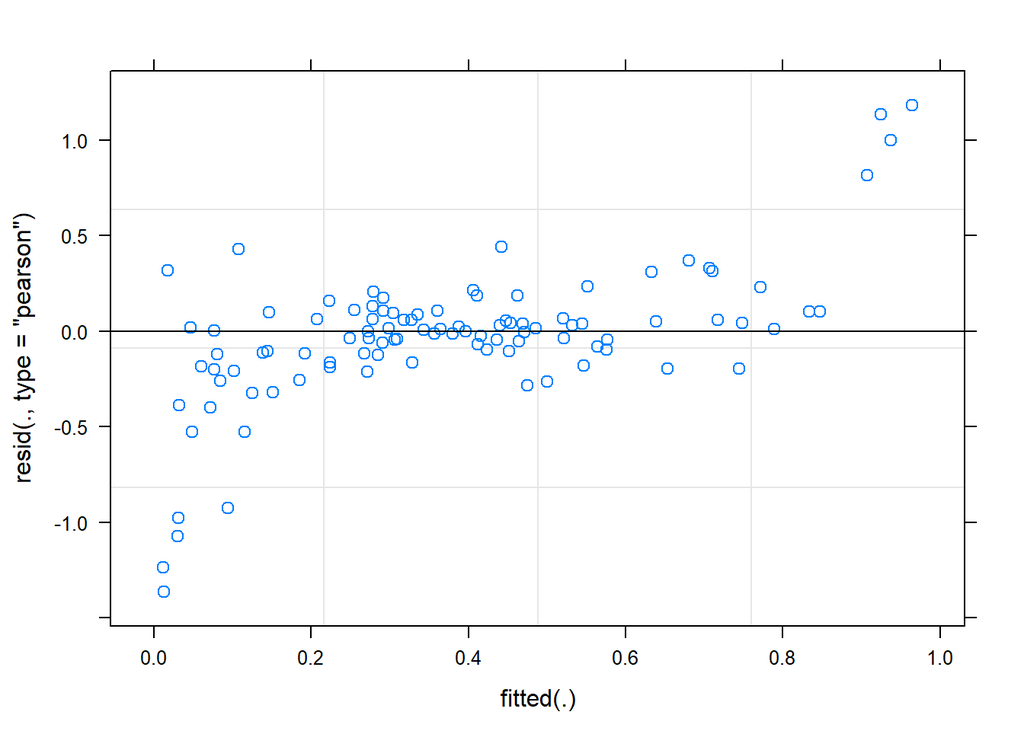

```r
  plot(glme.foc.e)  # not too bad
```

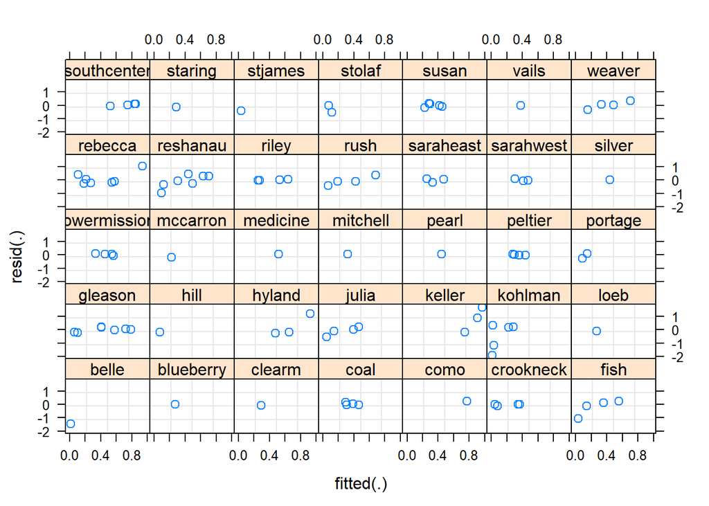

```r
  plot(glme.foc.e, resid(.)~ fitted(.) |Lake) # by group
```

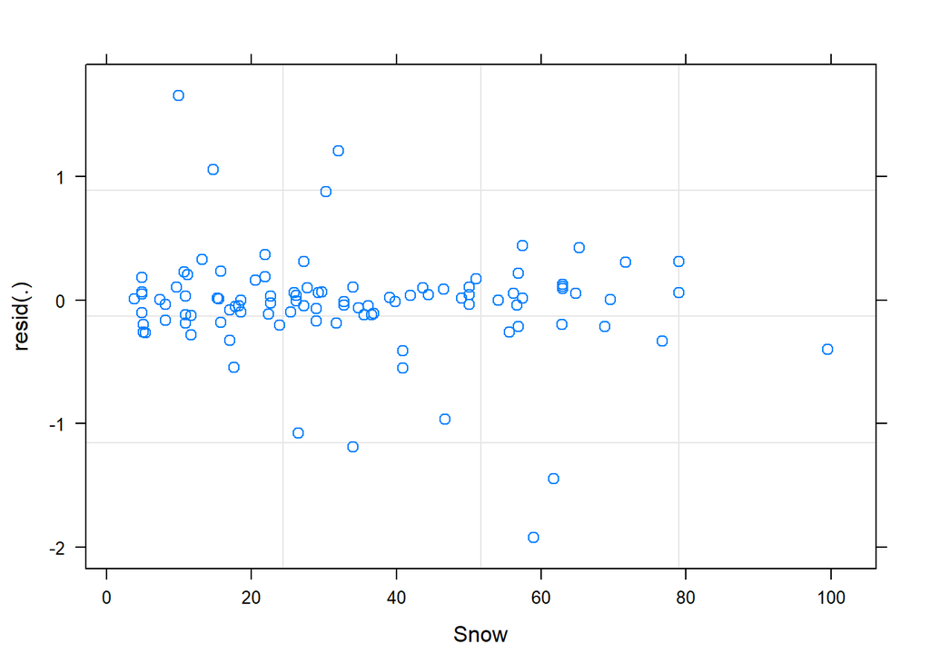

```r
  plot(glme.foc.e, resid(.)~ Snow)  # residuals versus Snow
```

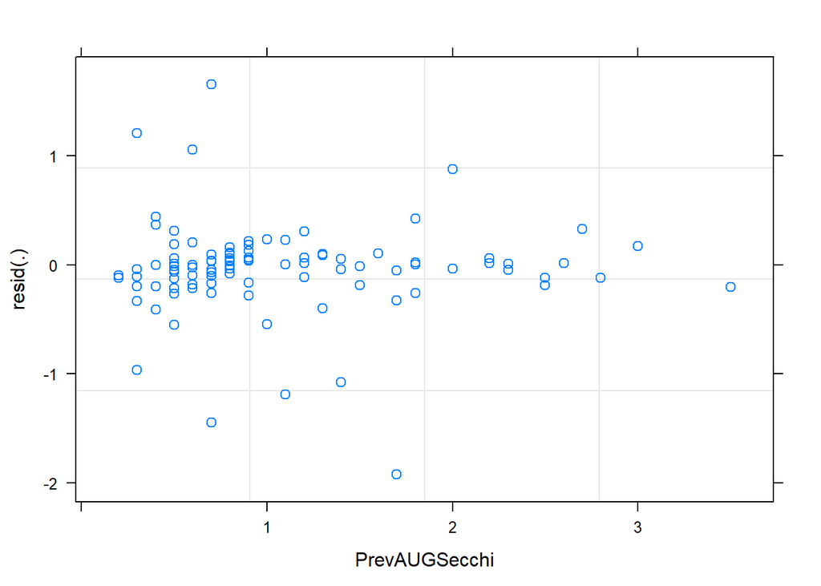

```r
  plot(glme.foc.e, resid(.)~ PrevAUGSecchi) #secchi
```

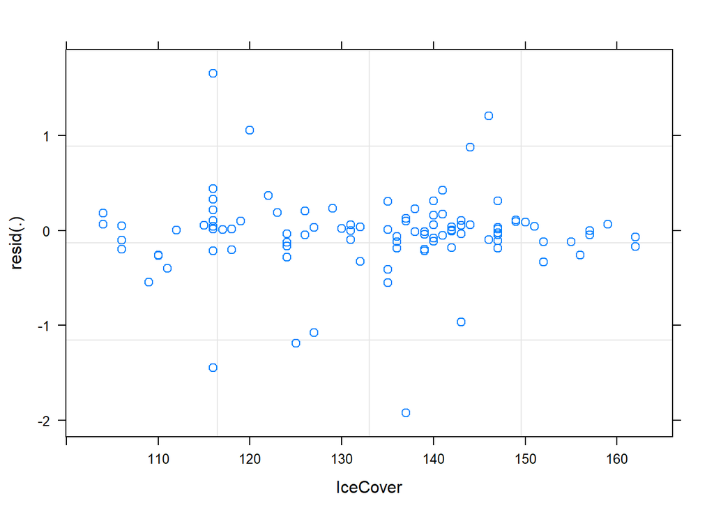

```r
  plot(glme.foc.e, resid(.)~ IceCover) # icecover
```

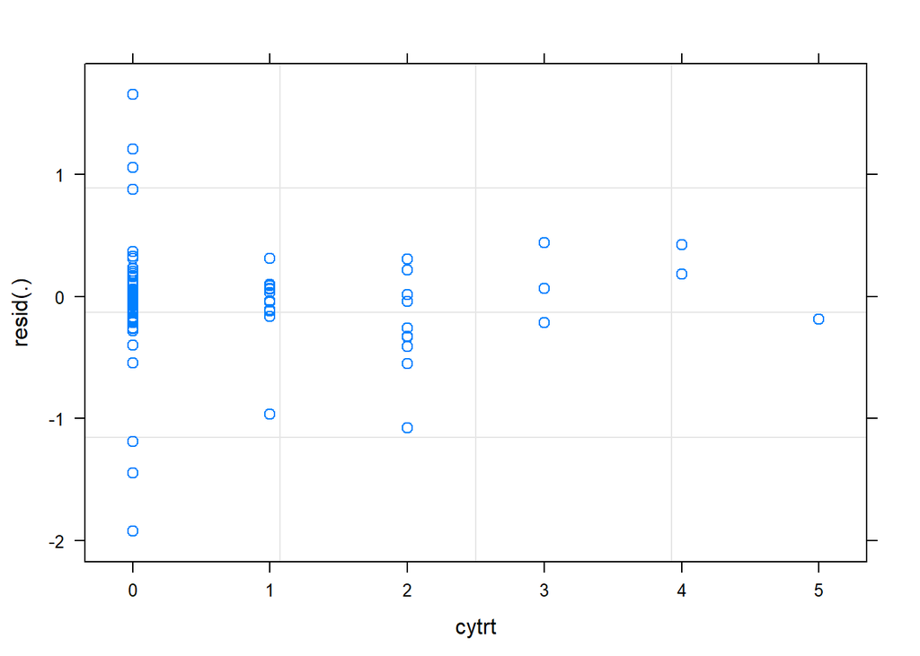

```r
  plot(glme.foc.e, resid(.)~ cytrt) # cytrt - def more var at low cytrt. That is also where most of our data lie
```

### Late Survey Freq

```r
  glme.foc.p <- glmer(foc_clp~ Trt + cytrt + PrevAUGSecchi.sc + Snow.sc + IceCover.sc +
                      (1 | Lake)+ (1 | obs), family = binomial(logit), data = pcri.p, weights = nsamp)
  summary(glme.foc.p)
```

```
## Generalized linear mixed model fit by maximum likelihood (Laplace
##   Approximation) [glmerMod]
##  Family: binomial  ( logit )
## Formula: foc_clp ~ Trt + cytrt + PrevAUGSecchi.sc + Snow.sc + IceCover.sc +
##     (1 | Lake) + (1 | obs)
##    Data: pcri.p
## Weights: nsamp
##
##      AIC      BIC   logLik deviance df.resid
##   1201.1   1224.9   -592.6   1185.1      137
##
## Scaled residuals:
##      Min       1Q   Median       3Q      Max
## -1.38306 -0.20861  0.00594  0.09084  0.93707
##
## Random effects:
##  Groups Name        Variance Std.Dev.
##  obs    (Intercept) 1.794    1.339
##  Lake   (Intercept) 1.882    1.372
## Number of obs: 145, groups:  obs, 145; Lake, 45
##
## Fixed effects:
##                  Estimate Std. Error z value Pr(>|z|)
## (Intercept)      -1.11214    0.27885  -3.988 6.65e-05 ***
## Trt1             -1.58941    0.36972  -4.299 1.72e-05 ***
## cytrt            -0.18458    0.14372  -1.284   0.1990
## PrevAUGSecchi.sc -0.44663    0.18191  -2.455   0.0141 *
## Snow.sc           0.07494    0.13829   0.542   0.5879
## IceCover.sc      -0.13352    0.14893  -0.897   0.3700
## ---
## Signif. codes:  0 '***' 0.001 '**' 0.01 '*' 0.05 '.' 0.1 ' ' 1
##
## Correlation of Fixed Effects:
##             (Intr) Trt1   cytrt  PAUGS. Snw.sc
## Trt1        -0.407
## cytrt       -0.021 -0.386
## PrvAUGScch. -0.135  0.193 -0.054
## Snow.sc     -0.086  0.102 -0.084 -0.028
## IceCover.sc  0.077 -0.193 -0.027 -0.037 -0.347
```

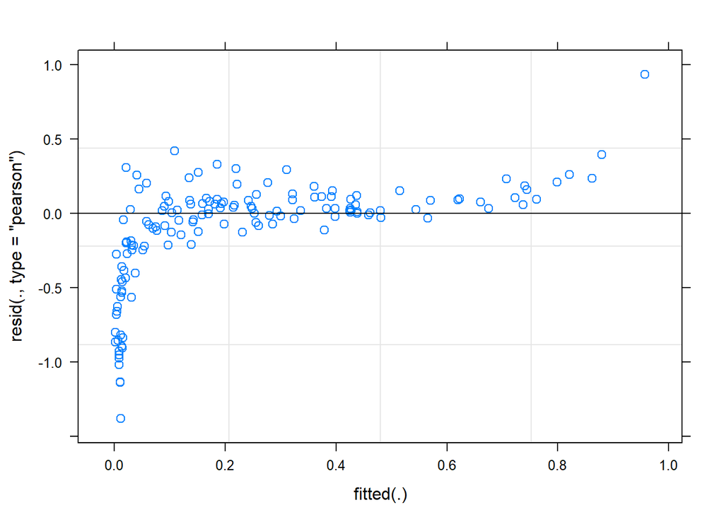

```r
  plot(glme.foc.p) # this also loks o.k. but note the tails again are a bit wonky
```

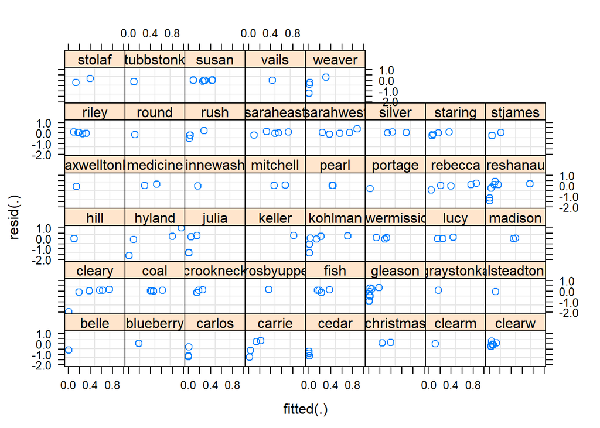

```r
  plot(glme.foc.p, resid(.)~ fitted(.) |Lake) # by group
```

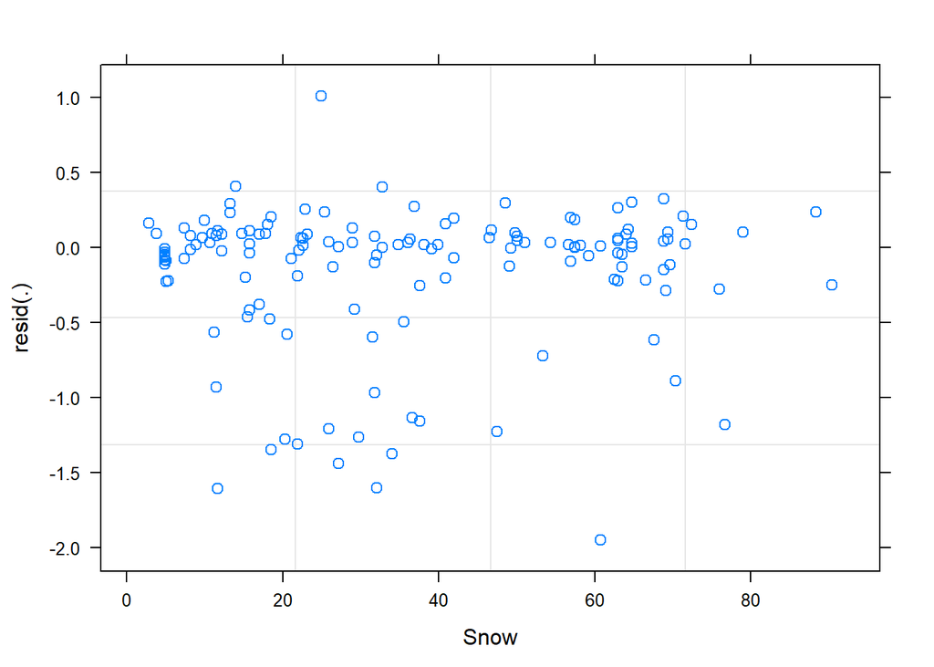

```r
  plot(glme.foc.p, resid(.)~ Snow)  # residuals versus Snow
```

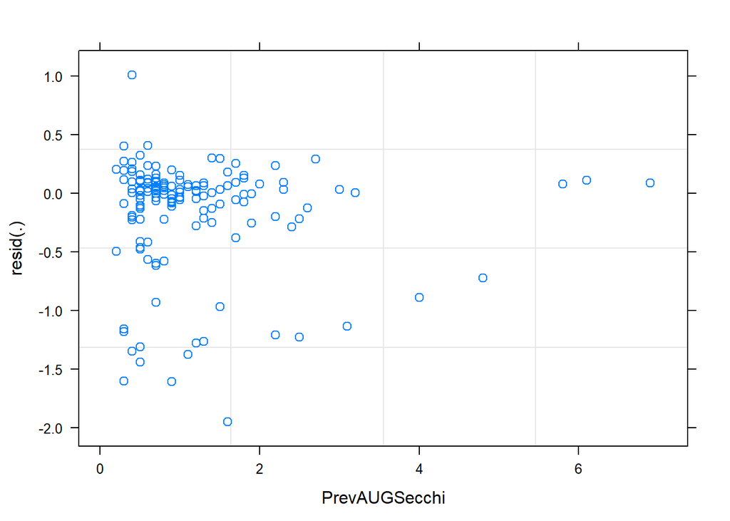

```r
  plot(glme.foc.p, resid(.)~ PrevAUGSecchi) #secchi- here we can see that the secchi data have relatively poor coverage past ~3.5m
```

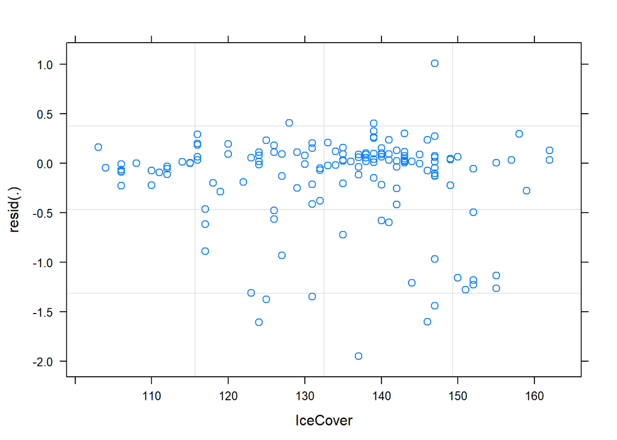

```r
  plot(glme.foc.p, resid(.)~ IceCover) # icecover
```

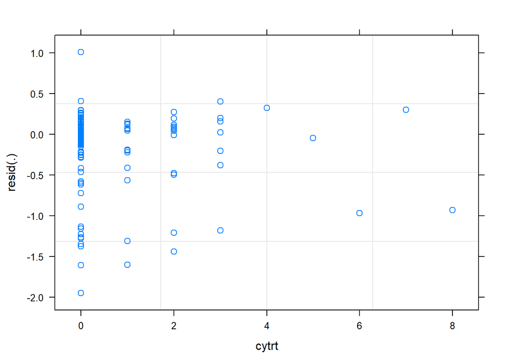

```r
  plot(glme.foc.p, resid(.)~ cytrt) # cytrt
```

### Early Survey Rake Density:

```r
  glme.rd.e <- glmer(rd_pcri~ Trte + cytrt + PrevAUGSecchi.sc + Snow.sc + IceCover.sc +
                      (1 | Lake), family = Gamma(inverse), data = pcri.e)
  summary(glme.rd.e)
```

```
## Generalized linear mixed model fit by maximum likelihood (Laplace
##   Approximation) [glmerMod]
##  Family: Gamma  ( inverse )
## Formula: rd_pcri ~ Trte + cytrt + PrevAUGSecchi.sc + Snow.sc + IceCover.sc +
##     (1 | Lake)
##    Data: pcri.e
##
##      AIC      BIC   logLik deviance df.resid
##     41.8     58.9    -12.9     25.8       55
##
## Scaled residuals:
##      Min       1Q   Median       3Q      Max
## -1.66066 -0.45020  0.02484  0.72711  1.82951
##
## Random effects:
##  Groups   Name        Variance Std.Dev.
##  Lake     (Intercept) 0.01357  0.1165
##  Residual             0.03853  0.1963
## Number of obs: 63, groups:  Lake, 19
##
## Fixed effects:
##                  Estimate Std. Error t value Pr(>|z|)
## (Intercept)       0.64090    0.05345  11.991  < 2e-16 ***
## Trte1             0.14935    0.03965   3.767 0.000165 ***
## cytrt             0.03142    0.01989   1.579 0.114226
## PrevAUGSecchi.sc  0.05625    0.03573   1.574 0.115423
## Snow.sc           0.01794    0.02046   0.876 0.380789
## IceCover.sc       0.02648    0.01764   1.501 0.133369
## ---
## Signif. codes:  0 '***' 0.001 '**' 0.01 '*' 0.05 '.' 0.1 ' ' 1
##
## Correlation of Fixed Effects:
##             (Intr) Trte1  cytrt  PAUGS. Snw.sc
## Trte1       -0.266
## cytrt       -0.037 -0.456
## PrvAUGScch.  0.216 -0.044 -0.194
## Snow.sc      0.147 -0.045 -0.092  0.111
## IceCover.sc -0.065 -0.130  0.071 -0.110 -0.611
```

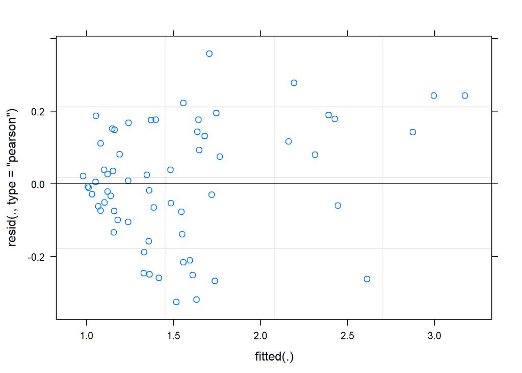

```r
  plot(glme.rd.e) # this looks o.k. but note the lack of data at large fitted vals
```

### Late Survey Rake Densities

```r
  glme.rd.p <- glmer(rd_pcri~ Trt + cytrt + PrevAUGSecchi.sc + Snow.sc + IceCover.sc +
                     (1 | Lake), family = Gamma(inverse), data = pcri.p)
  summary(glme.rd.p)
```

```
## Generalized linear mixed model fit by maximum likelihood (Laplace
##   Approximation) [glmerMod]
##  Family: Gamma  ( inverse )
## Formula: rd_pcri ~ Trt + cytrt + PrevAUGSecchi.sc + Snow.sc + IceCover.sc +
##     (1 | Lake)
##    Data: pcri.p
##
##      AIC      BIC   logLik deviance df.resid
##    116.2    135.3    -50.1    100.2       72
##
## Scaled residuals:
##     Min      1Q  Median      3Q     Max
## -1.8620 -0.5004 -0.2257  0.6633  2.3714
##
## Random effects:
##  Groups   Name        Variance Std.Dev.
##  Lake     (Intercept) 0.01745  0.1321
##  Residual             0.08545  0.2923
## Number of obs: 80, groups:  Lake, 28
##
## Fixed effects:
##                    Estimate Std. Error t value Pr(>|z|)
## (Intercept)       5.649e-01  5.400e-02  10.461  < 2e-16 ***
## Trt1              2.612e-01  6.232e-02   4.191 2.78e-05 ***
## cytrt             2.881e-02  2.137e-02   1.349   0.1775
## PrevAUGSecchi.sc  2.072e-02  2.895e-02   0.716   0.4740
## Snow.sc           4.676e-02  2.404e-02   1.945   0.0518 .
## IceCover.sc      -7.778e-06  2.551e-02   0.000   0.9998
## ---
## Signif. codes:  0 '***' 0.001 '**' 0.01 '*' 0.05 '.' 0.1 ' ' 1
##
## Correlation of Fixed Effects:
##             (Intr) Trt1   cytrt  PAUGS. Snw.sc
## Trt1        -0.391
## cytrt       -0.005 -0.330
## PrvAUGScch. -0.218  0.159 -0.098
## Snow.sc     -0.097  0.316 -0.088  0.015
## IceCover.sc  0.090 -0.335  0.043 -0.031 -0.574
```

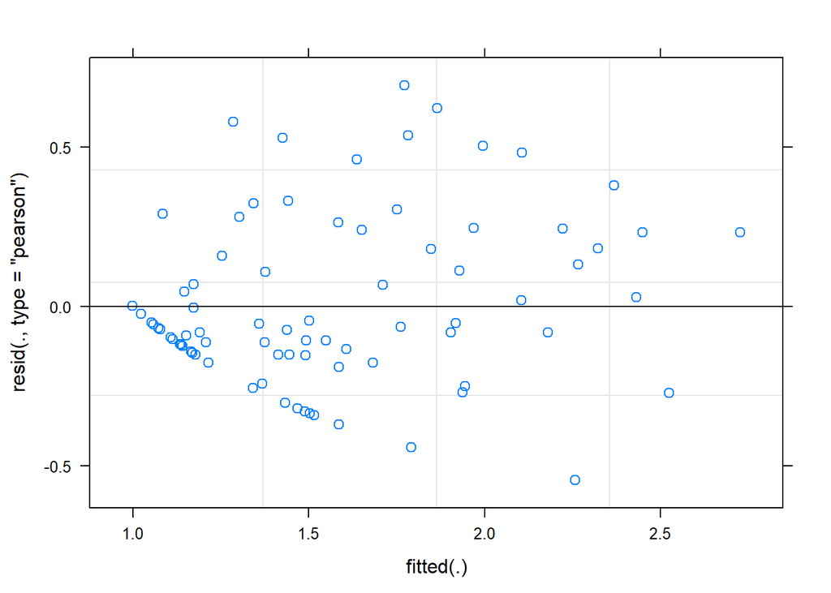

```r
  plot(glme.rd.p) # probably the best so far, but there is a weird lower bound on this one
```

```r
# mixed models with interactions by trt ------------------------------------------------
```

## Interactions (trt X env. var.)

In order to evaluate whether or not chemical treatements can “harness” the natural fluctuations of CLP, we need to test for interactions between treatment and our environmental variables. Our approach is thus to test for interactions, but retain only significant (p = .05) interactions for estimation of fixed effects.

### Late Surveys Freq

```r
  #peak foc
  glme.foc.p <- glmer(foc_clp~ Trt + cytrt + Trt*PrevAUGSecchi.sc + Trt*Snow.sc + Trt*IceCover.sc +
                        (1 | Lake)+ (1 | obs), family = binomial(logit), data = pcri.p, weights = nsamp)
```

```
## Warning in eval(family$initialize, rho): non-integer #successes in a binomial
## glm!
```

```
## Warning in checkConv(attr(opt, "derivs"), opt$par, ctrl = control$checkConv, :
## Model failed to converge with max|grad| = 0.01035 (tol = 0.001, component 1)
```

```r
  summary(glme.foc.p)
```

```
## Generalized linear mixed model fit by maximum likelihood (Laplace
##   Approximation) [glmerMod]
##  Family: binomial  ( logit )
## Formula: foc_clp ~ Trt + cytrt + Trt * PrevAUGSecchi.sc + Trt * Snow.sc +
##     Trt * IceCover.sc + (1 | Lake) + (1 | obs)
##    Data: pcri.p
## Weights: nsamp
##
##      AIC      BIC   logLik deviance df.resid
##   1196.0   1228.7   -587.0   1174.0      134
##
## Scaled residuals:
##      Min       1Q   Median       3Q      Max
## -1.38820 -0.19301 -0.00007  0.09729  0.88716
##
## Random effects:
##  Groups Name        Variance Std.Dev.
##  obs    (Intercept) 1.627    1.276
##  Lake   (Intercept) 1.737    1.318
## Number of obs: 145, groups:  obs, 145; Lake, 45
##
## Fixed effects:
##                       Estimate Std. Error z value Pr(>|z|)
## (Intercept)           -1.03954    0.26826  -3.875 0.000107 ***
## Trt1                  -1.07594    0.39012  -2.758 0.005816 **
## cytrt                 -0.29859    0.14546  -2.053 0.040101 *
## PrevAUGSecchi.sc      -0.54937    0.18678  -2.941 0.003269 **
## Snow.sc               -0.15291    0.16653  -0.918 0.358504
## IceCover.sc           -0.08506    0.18113  -0.470 0.638646
## Trt1:PrevAUGSecchi.sc  1.14252    0.48057   2.377 0.017434 *
## Trt1:Snow.sc           0.75621    0.28976   2.610 0.009059 **
## Trt1:IceCover.sc      -0.11486    0.29774  -0.386 0.699666
## ---
## Signif. codes:  0 '***' 0.001 '**' 0.01 '*' 0.05 '.' 0.1 ' ' 1
##
## Correlation of Fixed Effects:
##             (Intr) Trt1   cytrt  PAUGS. Snw.sc IcCvr. T1:PAU Tr1:S.
## Trt1        -0.337
## cytrt       -0.039 -0.431
## PrvAUGScch. -0.137  0.055 -0.026
## Snow.sc     -0.080 -0.008  0.031 -0.088
## IceCover.sc  0.025 -0.080  0.001 -0.091 -0.262
## Trt1:PAUGS.  0.061  0.390 -0.154 -0.318  0.049  0.058
## Trt1:Snw.sc  0.025  0.208 -0.194  0.051 -0.595  0.133  0.084
## Trt1:IcCvr.  0.055 -0.059 -0.032  0.049  0.158 -0.607  0.032 -0.338
## convergence code: 0
## Model failed to converge with max|grad| = 0.01035 (tol = 0.001, component 1)
```

Why the warnings? There are a few weird values in there, thus “fit with non-integer data”. These are likely the lakes where I used Adam’s calculated values.

```r
  pcri.p[ , nsamp*foc_clp] # note non-integer values
```

```
##   [1]   0.00   2.00  95.00  22.00   4.00   7.00   0.00  54.00  44.00  31.00
##  [11]  35.00  18.00  28.00  50.00  18.00  60.86  35.00  37.00  39.00  26.00
##  [21]  10.00  11.00  38.00  18.00  57.00  63.00  28.00  31.00   0.00   0.00
##  [31]   2.00 116.00 100.00  11.00   0.00   0.00 122.00  85.00   3.00  13.00
##  [41]   9.00  12.00  29.00  65.00   1.00   1.00   1.00   5.00  19.00   2.00
##  [51]   0.00   3.00   0.00  25.00  45.00  35.00   2.00   0.00   1.00  39.00
##  [61]  19.00  54.00   9.00  26.00  44.00  36.00   5.04  77.00  40.00  27.00
##  [71]   8.00  36.00  51.00  35.00  24.00   2.00 114.00 126.00   5.00  33.00
##  [81]  62.00   6.00   0.00   0.00   1.00   8.00  13.00   2.00  23.00  25.00
##  [91]  37.00  22.00   0.00   0.00   0.00  62.78  34.00  69.00 101.00   1.00
## [101]   1.00  32.00   4.00  17.92   0.00   2.00  14.00  58.00   0.00 120.00
## [111]  94.00  99.00  47.00  24.00  20.00  28.00 264.00 308.00   0.00   0.00
## [121]  17.00   5.00  32.00   3.00   1.00   2.00 180.00 180.00  77.00  38.00
## [131]  50.00  35.00  36.00  72.00  21.00   6.00   5.00   8.00   3.00   7.00
## [141]   3.00   7.00  14.00  26.00   7.00
```

Why non-convergence? Explore a few reasons (adapted from https://rstudio-pubs-static.s3.amazonaws.com/33653_57fc7b8e5d484c909b615d8633c01d51.html):

```r
  # a singularity?
  tt <- getME(glme.foc.p,"theta")
  ll <- getME(glme.foc.p,"lower")
  min(tt[ll==0]) # likely not because of a singularity
```

```
## [1] 1.275533
```

```r
  # a gradient calculation error?
  derivs1 <- glme.foc.p@optinfo$derivs
  sc_grad1 <- with(derivs1,solve(Hessian,gradient))
  max(abs(sc_grad1))
```

```
## [1] 0.002362967
```

```r
  max(pmin(abs(sc_grad1),abs(derivs1$gradient)))
```

```
## [1] 0.002362967
```

```r
  dd <- update(glme.foc.p,devFunOnly=TRUE)
  pars <- unlist(getME(glme.foc.p,c("theta","fixef")))
    grad2 <- grad(dd,pars)
  hess2 <- hessian(dd,pars)
  sc_grad2 <- solve(hess2,grad2)
  max(pmin(abs(sc_grad2),abs(grad2))) # not lack of gradient (usually set to require > 0.001)
```

```
## [1] 0.00235688
```

```r
  # Restart from previous fit:
  ss <- getME(glme.foc.p,c("theta","fixef"))
  glme.foc.p2 <- update(glme.foc.p,start=ss,control=glmerControl(optCtrl=list(maxfun=2e4)))
  # that worked
  summary(glme.foc.p2)
```

```
## Generalized linear mixed model fit by maximum likelihood (Laplace
##   Approximation) [glmerMod]
##  Family: binomial  ( logit )
## Formula: foc_clp ~ Trt + cytrt + Trt * PrevAUGSecchi.sc + Trt * Snow.sc +
##     Trt * IceCover.sc + (1 | Lake) + (1 | obs)
##    Data: pcri.p
## Weights: nsamp
## Control: glmerControl(optCtrl = list(maxfun = 20000))
##
##      AIC      BIC   logLik deviance df.resid
##   1196.0   1228.7   -587.0   1174.0      134
##
## Scaled residuals:
##      Min       1Q   Median       3Q      Max
## -1.38863 -0.19293 -0.00005  0.09743  0.88757
##
## Random effects:
##  Groups Name        Variance Std.Dev.
##  obs    (Intercept) 1.626    1.275
##  Lake   (Intercept) 1.739    1.319
## Number of obs: 145, groups:  obs, 145; Lake, 45
##
## Fixed effects:
##                       Estimate Std. Error z value Pr(>|z|)
## (Intercept)           -1.03967    0.26834  -3.874 0.000107 ***
## Trt1                  -1.07719    0.39005  -2.762 0.005750 **
## cytrt                 -0.29873    0.14542  -2.054 0.039955 *
## PrevAUGSecchi.sc      -0.54976    0.18684  -2.942 0.003257 **
## Snow.sc               -0.15325    0.16648  -0.921 0.357308
## IceCover.sc           -0.08469    0.18108  -0.468 0.639978
## Trt1:PrevAUGSecchi.sc  1.14019    0.48053   2.373 0.017654 *
## Trt1:Snow.sc           0.75560    0.28966   2.609 0.009092 **
## Trt1:IceCover.sc      -0.11417    0.29765  -0.384 0.701292
## ---
## Signif. codes:  0 '***' 0.001 '**' 0.01 '*' 0.05 '.' 0.1 ' ' 1
##
## Correlation of Fixed Effects:
##             (Intr) Trt1   cytrt  PAUGS. Snw.sc IcCvr. T1:PAU Tr1:S.
## Trt1        -0.337
## cytrt       -0.039 -0.430
## PrvAUGScch. -0.137  0.055 -0.026
## Snow.sc     -0.079 -0.008  0.031 -0.088
## IceCover.sc  0.025 -0.080  0.001 -0.091 -0.262
## Trt1:PAUGS.  0.061  0.390 -0.154 -0.318  0.049  0.058
## Trt1:Snw.sc  0.025  0.208 -0.194  0.051 -0.595  0.133  0.084
## Trt1:IcCvr.  0.055 -0.059 -0.032  0.049  0.158 -0.607  0.032 -0.338
```

```r
  #then retain significant interactions (PAUGSecchi & Snow):
  glme.foc.p <- glmer(foc_clp~ Trt + cytrt + PrevAUGSecchi.sc+ Snow.sc + IceCover.sc  + Trt:PrevAUGSecchi.sc + Trt:Snow.sc+
                        (1 | Lake)+ (1 | obs), family = binomial(logit), data = pcri.p, weights = nsamp)
  #model.matrix(glme.foc.p)
  summary(glme.foc.p)
```

```
## Generalized linear mixed model fit by maximum likelihood (Laplace
##   Approximation) [glmerMod]
##  Family: binomial  ( logit )
## Formula: foc_clp ~ Trt + cytrt + PrevAUGSecchi.sc + Snow.sc + IceCover.sc +
##     Trt:PrevAUGSecchi.sc + Trt:Snow.sc + (1 | Lake) + (1 | obs)
##    Data: pcri.p
## Weights: nsamp
##
##      AIC      BIC   logLik deviance df.resid
##   1194.1   1223.9   -587.1   1174.1      135
##
## Scaled residuals:
##      Min       1Q   Median       3Q      Max
## -1.38658 -0.19658  0.00133  0.09733  0.89071
##
## Random effects:
##  Groups Name        Variance Std.Dev.
##  obs    (Intercept) 1.629    1.276
##  Lake   (Intercept) 1.728    1.315
## Number of obs: 145, groups:  obs, 145; Lake, 45
##
## Fixed effects:
##                       Estimate Std. Error z value Pr(>|z|)
## (Intercept)            -1.0343     0.2676  -3.865 0.000111 ***
## Trt1                   -1.0859     0.3897  -2.786 0.005329 **
## cytrt                  -0.3002     0.1453  -2.067 0.038746 *
## PrevAUGSecchi.sc       -0.5457     0.1862  -2.930 0.003388 **
## Snow.sc                -0.1430     0.1644  -0.870 0.384452
## IceCover.sc            -0.1270     0.1439  -0.883 0.377422
## Trt1:PrevAUGSecchi.sc   1.1458     0.4801   2.387 0.016993 *
## Trt1:Snow.sc            0.7181     0.2729   2.632 0.008500 **
## ---
## Signif. codes:  0 '***' 0.001 '**' 0.01 '*' 0.05 '.' 0.1 ' ' 1
##
## Correlation of Fixed Effects:
##             (Intr) Trt1   cytrt  PAUGS. Snw.sc IcCvr. T1:PAU
## Trt1        -0.336
## cytrt       -0.037 -0.434
## PrvAUGScch. -0.141  0.059 -0.024
## Snow.sc     -0.089  0.000  0.036 -0.097
## IceCover.sc  0.075 -0.147 -0.023 -0.077 -0.211
## Trt1:PAUGS.  0.060  0.391 -0.153 -0.320  0.044  0.098
## Trt1:Snw.sc  0.045  0.202 -0.217  0.072 -0.583 -0.098  0.101
```

So we can see that the secchi and snow slopes are different in Trt v Untrt lakes, but but now we want to ask if the values for the Trt interactions are significantly non-zero (vs. sig diff from UNtrt). To do this we’ll flip our intercept value, and estimate the slopes for treated lakes first:

```r
  str(pcri.p)
```

```
## Classes 'data.table' and 'data.frame':   145 obs. of  32 variables:
##  $ Lake.ID            : int  2000900 2000900 2000900 2000900 2000900 2000900 2000900 10000200 10000200 10000200 ...
##  $ Year               : int  2008 2009 2010 2011 2012 2013 2014 2011 2012 2013 ...
##  $ Lake               : Factor w/ 45 levels "belle","blueberry",..: 32 32 32 32 32 32 32 33 33 33 ...
##  $ Latitude.x         : num  45.2 45.2 45.2 45.2 45.2 ...
##  $ Trt                : Factor w/ 2 levels "0","1": 2 2 1 2 2 2 2 1 1 2 ...
##  $ YrsTrt             : int  4 5 0 1 2 0 1 0 0 1 ...
##  $ PrevAUGSecchi      : num  0.5 0.3 0.4 0.5 0.5 0.3 0.3 1 0.9 0.8 ...
##  $ IceIn              : chr  "28-Nov" "22-Nov" "6-Dec" "24-Nov" ...
##  $ IceOut             : chr  "22-Apr" "9-Apr" "31-Mar" "12-Apr" ...
##  $ IceCover           : int  147 139 116 140 110 143 152 137 106 147 ...
##  $ Snow               : num  27.18 32.77 57.4 78.99 5.33 ...
##  $ Longitude          : num  -93.1 -93.1 -93.1 -93.1 -93.1 ...
##  $ Ecoregion          : chr  "NCHF" "NCHF" "NCHF" "NCHF" ...
##  $ Lake.area..ha.     : num  136 136 136 136 136 136 136 120 120 120 ...
```

[output cut: 19 more lines]

```r
  pcri.p$TrtN <- as.numeric(pcri.p$Trt == 0)
  pcri.p[,.(Trt,TrtN)]
```

```
##      Trt TrtN
##   1:   1    0
##   2:   1    0
##   3:   0    1
##   4:   1    0
##   5:   1    0
##  ---
## 141:   0    1
## 142:   0    1
## 143:   0    1
## 144:   0    1
## 145:   0    1
```

```r
  glme.foc.p.a <- glmer(foc_clp ~
                         TrtN + cytrt +
                         + IceCover.sc +
                         TrtN*PrevAUGSecchi.sc + TrtN*Snow.sc+
                      (1 | Lake)+ (1 | obs), family = binomial(logit), data = pcri.p, weights = nsamp)
  # model.matrix(glme.foc.p.a)

  # Restart from previous fit:
  ss <- getME(glme.foc.p.a ,c("theta","fixef"))
  glme.foc.p.a2 <- update(glme.foc.p.a,start=ss,control=glmerControl(optCtrl=list(maxfun=2e4)))
  summary(glme.foc.p.a2) # ests for treated slopes as intercepts
```

```
## Generalized linear mixed model fit by maximum likelihood (Laplace
##   Approximation) [glmerMod]
##  Family: binomial  ( logit )
## Formula: foc_clp ~ TrtN + cytrt + +IceCover.sc + TrtN * PrevAUGSecchi.sc +
##     TrtN * Snow.sc + (1 | Lake) + (1 | obs)
##    Data: pcri.p
## Weights: nsamp
## Control: glmerControl(optCtrl = list(maxfun = 20000))
##
##      AIC      BIC   logLik deviance df.resid
##   1194.1   1223.9   -587.1   1174.1      135
##
## Scaled residuals:
##      Min       1Q   Median       3Q      Max
## -1.38657 -0.19658  0.00133  0.09733  0.89070
##
## Random effects:
##  Groups Name        Variance Std.Dev.
##  obs    (Intercept) 1.629    1.276
##  Lake   (Intercept) 1.728    1.315
## Number of obs: 145, groups:  obs, 145; Lake, 45
##
## Fixed effects:
##                       Estimate Std. Error z value Pr(>|z|)
## (Intercept)            -2.1203     0.3917  -5.414 6.18e-08 ***
## TrtN                    1.0859     0.3897   2.787  0.00533 **
## cytrt                  -0.3002     0.1453  -2.067  0.03877 *
## IceCover.sc            -0.1270     0.1439  -0.883  0.37744
## PrevAUGSecchi.sc        0.6001     0.4560   1.316  0.18818
## Snow.sc                 0.5751     0.2218   2.593  0.00951 **
## TrtN:PrevAUGSecchi.sc  -1.1458     0.4801  -2.387  0.01699 *
## TrtN:Snow.sc           -0.7181     0.2729  -2.631  0.00850 **
## ---
## Signif. codes:  0 '***' 0.001 '**' 0.01 '*' 0.05 '.' 0.1 ' ' 1
##
## Correlation of Fixed Effects:
##             (Intr) TrtN   cytrt  IcCvr. PAUGS. Snw.sc TN:PAU
## TrtN        -0.765
## cytrt       -0.457  0.434
## IceCover.sc -0.095  0.147 -0.023
## PrvAUGScch.  0.438 -0.436 -0.171  0.071
## Snow.sc      0.240 -0.248 -0.240 -0.277  0.172
## TrtN:PAUGS. -0.430  0.391  0.153 -0.098 -0.922 -0.157
## TrtN:Snw.sc -0.232  0.202  0.217  0.098 -0.136 -0.798  0.101
```

```r
  summary(glme.foc.p) # ests for untreated slopes as intercepts
```

```
## Generalized linear mixed model fit by maximum likelihood (Laplace
##   Approximation) [glmerMod]
##  Family: binomial  ( logit )
## Formula: foc_clp ~ Trt + cytrt + PrevAUGSecchi.sc + Snow.sc + IceCover.sc +
##     Trt:PrevAUGSecchi.sc + Trt:Snow.sc + (1 | Lake) + (1 | obs)
##    Data: pcri.p
## Weights: nsamp
##
##      AIC      BIC   logLik deviance df.resid
##   1194.1   1223.9   -587.1   1174.1      135
##
## Scaled residuals:
##      Min       1Q   Median       3Q      Max
## -1.38658 -0.19658  0.00133  0.09733  0.89071
##
## Random effects:
##  Groups Name        Variance Std.Dev.
##  obs    (Intercept) 1.629    1.276
##  Lake   (Intercept) 1.728    1.315
## Number of obs: 145, groups:  obs, 145; Lake, 45
##
## Fixed effects:
##                       Estimate Std. Error z value Pr(>|z|)
## (Intercept)            -1.0343     0.2676  -3.865 0.000111 ***
## Trt1                   -1.0859     0.3897  -2.786 0.005329 **
## cytrt                  -0.3002     0.1453  -2.067 0.038746 *
## PrevAUGSecchi.sc       -0.5457     0.1862  -2.930 0.003388 **
## Snow.sc                -0.1430     0.1644  -0.870 0.384452
## IceCover.sc            -0.1270     0.1439  -0.883 0.377422
## Trt1:PrevAUGSecchi.sc   1.1458     0.4801   2.387 0.016993 *
## Trt1:Snow.sc            0.7181     0.2729   2.632 0.008500 **
## ---
## Signif. codes:  0 '***' 0.001 '**' 0.01 '*' 0.05 '.' 0.1 ' ' 1
##
## Correlation of Fixed Effects:
##             (Intr) Trt1   cytrt  PAUGS. Snw.sc IcCvr. T1:PAU
## Trt1        -0.336
## cytrt       -0.037 -0.434
## PrvAUGScch. -0.141  0.059 -0.024
## Snow.sc     -0.089  0.000  0.036 -0.097
## IceCover.sc  0.075 -0.147 -0.023 -0.077 -0.211
## Trt1:PAUGS.  0.060  0.391 -0.153 -0.320  0.044  0.098
## Trt1:Snw.sc  0.045  0.202 -0.217  0.072 -0.583 -0.098  0.101
```

So secchi is non-significant in the treated lakes, whereas snow has a significantly positive effect on clp growth in the treated subset.From these models we can say that the influence on peak clp freq are: trt(-), cytrt (-), Prev Secchi (- in untrt lakes, non-sig in trt lakes), and Snow (non-sig in untrt lakes, but + in Trt lakes), ice cover (non-sig).

### Early Surveys Freq

```r
  #early foc
  glme.foc.e <- glmer(foc_clp~ Trte + cytrt + PrevAUGSecchi.sc*Trte + Snow.sc*Trte + IceCover.sc*Trte +
                        (1 | Lake)+ (1 | obs), family = binomial(logit), data = pcri.e, weights = nsamp)
  summary(glme.foc.e)
```

```
## Generalized linear mixed model fit by maximum likelihood (Laplace
##   Approximation) [glmerMod]
##  Family: binomial  ( logit )
## Formula: foc_clp ~ Trte + cytrt + PrevAUGSecchi.sc * Trte + Snow.sc *
##     Trte + IceCover.sc * Trte + (1 | Lake) + (1 | obs)
##    Data: pcri.e
## Weights: nsamp
##
##      AIC      BIC   logLik deviance df.resid
##    918.2    947.0   -448.1    896.2       90
##
## Scaled residuals:
##      Min       1Q   Median       3Q      Max
## -1.30810 -0.13048  0.00094  0.11270  1.24141
##
## Random effects:
##  Groups Name        Variance Std.Dev.
##  obs    (Intercept) 0.6120   0.7823
##  Lake   (Intercept) 0.9521   0.9757
## Number of obs: 101, groups:  obs, 101; Lake, 35
##
## Fixed effects:
##                          Estimate Std. Error z value Pr(>|z|)
## (Intercept)            -0.5424718  0.2149516  -2.524  0.01161 *
## Trte1                  -0.3303027  0.2597987  -1.271  0.20359
## cytrt                  -0.4966936  0.1204203  -4.125 3.71e-05 ***
## PrevAUGSecchi.sc       -0.3539969  0.2273198  -1.557  0.11941
## Snow.sc                -0.4924664  0.1522249  -3.235  0.00122 **
## IceCover.sc             0.0649542  0.1445845   0.449  0.65325
## Trte1:PrevAUGSecchi.sc -0.3600133  0.3210735  -1.121  0.26217
## Trte1:Snow.sc           0.0004073  0.2287247   0.002  0.99858
## Trte1:IceCover.sc      -0.1484899  0.2041444  -0.727  0.46700
## ---
## Signif. codes:  0 '***' 0.001 '**' 0.01 '*' 0.05 '.' 0.1 ' ' 1
##
## Correlation of Fixed Effects:
##             (Intr) Trte1  cytrt  PAUGS. Snw.sc IcCvr. T1:PAU Tr1:S.
## Trte1       -0.340
## cytrt       -0.011 -0.500
## PrvAUGScch.  0.125 -0.115 -0.128
## Snow.sc      0.083 -0.244  0.035  0.014
## IceCover.sc  0.119 -0.035 -0.026  0.031 -0.150
## Trt1:PAUGS. -0.045  0.393 -0.247 -0.443 -0.127 -0.002
## Trt1:Snw.sc -0.039  0.256 -0.155 -0.025 -0.651  0.147  0.212
## Trt1:IcCvr. -0.073 -0.025  0.006  0.022  0.082 -0.697 -0.008 -0.348
```

```r
  #no interactions are significant so include none:
  glme.foc.e <- glmer(foc_clp~ Trte + cytrt +  PrevAUGSecchi.sc + Snow.sc + IceCover.sc +
                        (1 | Lake)+ (1 | obs), family = binomial(logit), data = pcri.e, weights = nsamp)
  # model.matrix(glme.foc.e)
  summary(glme.foc.e)
```

```
## Generalized linear mixed model fit by maximum likelihood (Laplace
##   Approximation) [glmerMod]
##  Family: binomial  ( logit )
## Formula: foc_clp ~ Trte + cytrt + PrevAUGSecchi.sc + Snow.sc + IceCover.sc +
##     (1 | Lake) + (1 | obs)
##    Data: pcri.e
## Weights: nsamp
##
##      AIC      BIC   logLik deviance df.resid
##    914.0    934.9   -449.0    898.0       93
##
## Scaled residuals:
##      Min       1Q   Median       3Q      Max
## -1.36412 -0.12555 -0.00206  0.10055  1.18301
##
## Random effects:
##  Groups Name        Variance Std.Dev.
##  obs    (Intercept) 0.6224   0.7889
##  Lake   (Intercept) 0.9775   0.9887
## Number of obs: 101, groups:  obs, 101; Lake, 35
##
## Fixed effects:
##                   Estimate Std. Error z value Pr(>|z|)
## (Intercept)      -0.564845   0.216086  -2.614  0.00895 **
## Trte1            -0.219452   0.236166  -0.929  0.35277
## cytrt            -0.529424   0.116909  -4.529 5.94e-06 ***
## PrevAUGSecchi.sc -0.464942   0.204855  -2.270  0.02323 *
## Snow.sc          -0.508611   0.113872  -4.467 7.95e-06 ***
## IceCover.sc      -0.008906   0.103509  -0.086  0.93143
## ---
## Signif. codes:  0 '***' 0.001 '**' 0.01 '*' 0.05 '.' 0.1 ' ' 1
##
## Correlation of Fixed Effects:
##             (Intr) Trte1  cytrt  PAUGS. Snw.sc
## Trte1       -0.349
## cytrt       -0.029 -0.441
## PrvAUGScch.  0.124  0.055 -0.267
## Snow.sc      0.061 -0.111 -0.097  0.015
## IceCover.sc  0.087 -0.049 -0.050  0.080 -0.305
```

Early freq affected by cumulative yrs of treatment (-), productivity (+), and snow cover (-), whereas ice had no effect.

### Early Rake Density

```r
  glme.rd.e <- glmer(rd_pcri~ Trte + cytrt + PrevAUGSecchi.sc*Trte + Snow.sc*Trte + IceCover.sc*Trte +
                       (1 | Lake), family = Gamma(link = "log"), data = pcri.e)
  #restart at last fit:
  ss <- getME(glme.rd.e,c("theta","fixef"))
  glme.rd.e2 <- update(glme.rd.e,start=ss,control=glmerControl(optCtrl=list(maxfun=2e4)))
  # worked again
  summary(glme.rd.e2)
```

```
## Generalized linear mixed model fit by maximum likelihood (Laplace
##   Approximation) [glmerMod]
##  Family: Gamma  ( log )
## Formula: rd_pcri ~ Trte + cytrt + PrevAUGSecchi.sc * Trte + Snow.sc *
##     Trte + IceCover.sc * Trte + (1 | Lake)
##    Data: pcri.e
## Control: glmerControl(optCtrl = list(maxfun = 20000))
##
##      AIC      BIC   logLik deviance df.resid
##     56.1     79.7    -17.1     34.1       52
##
## Scaled residuals:
##     Min      1Q  Median      3Q     Max
## -1.7827 -0.6004  0.0420  0.6780  1.8570
##
## Random effects:
##  Groups   Name        Variance Std.Dev.
##  Lake     (Intercept) 0.03438  0.1854
##  Residual             0.04193  0.2048
## Number of obs: 63, groups:  Lake, 19
##
## Fixed effects:
##                        Estimate Std. Error t value Pr(>|z|)
## (Intercept)             0.51905    0.08773   5.917 3.29e-09 ***
## Trte1                  -0.20024    0.07655  -2.616   0.0089 **
## cytrt                  -0.03689    0.03075  -1.200   0.2303
## PrevAUGSecchi.sc       -0.12413    0.07334  -1.693   0.0905 .
## Snow.sc                -0.01873    0.05094  -0.368   0.7131
## IceCover.sc            -0.11262    0.04596  -2.450   0.0143 *
## Trte1:PrevAUGSecchi.sc  0.02424    0.08723   0.278   0.7811
## Trte1:Snow.sc           0.00971    0.07128   0.136   0.8916
## Trte1:IceCover.sc       0.11180    0.06042   1.850   0.0643 .
## ---
## Signif. codes:  0 '***' 0.001 '**' 0.01 '*' 0.05 '.' 0.1 ' ' 1
##
## Correlation of Fixed Effects:
##             (Intr) Trte1  cytrt  PAUGS. Snw.sc IcCvr. T1:PAU Tr1:S.
## Trte1       -0.303
## cytrt       -0.024 -0.454
## PrvAUGScch.  0.231 -0.119 -0.136
## Snow.sc      0.116 -0.253  0.106 -0.022
## IceCover.sc -0.040  0.017 -0.060 -0.074 -0.470
## Trt1:PAUGS. -0.094  0.374 -0.203 -0.379 -0.232  0.098
## Trt1:Snw.sc -0.058  0.345 -0.278  0.013 -0.702  0.339  0.318
## Trt1:IcCvr.  0.019 -0.125  0.082  0.100  0.317 -0.720 -0.136 -0.483
```

```r
  # retain no interactions
  glme.rd.e <- glmer(rd_pcri~ Trte + cytrt + PrevAUGSecchi.sc + Snow.sc + IceCover.sc + (1 | Lake), family = Gamma(link = "log"), data = pcri.e)
  summary(glme.rd.e)
```

```
## Generalized linear mixed model fit by maximum likelihood (Laplace
##   Approximation) [glmerMod]
##  Family: Gamma  ( log )
## Formula: rd_pcri ~ Trte + cytrt + PrevAUGSecchi.sc + Snow.sc + IceCover.sc +
##     (1 | Lake)
##    Data: pcri.e
##
##      AIC      BIC   logLik deviance df.resid
##     54.8     71.9    -19.4     38.8       55
##
## Scaled residuals:
##      Min       1Q   Median       3Q      Max
## -1.69128 -0.60532  0.00492  0.58267  2.09493
##
## Random effects:
##  Groups   Name        Variance Std.Dev.
##  Lake     (Intercept) 0.03594  0.1896
##  Residual             0.04510  0.2124
## Number of obs: 63, groups:  Lake, 19
##
## Fixed effects:
##                  Estimate Std. Error t value Pr(>|z|)
## (Intercept)       0.52467    0.08930   5.875 4.22e-09 ***
## Trte1            -0.21914    0.07106  -3.084  0.00204 **
## cytrt            -0.03077    0.03057  -1.007  0.31412
## PrevAUGSecchi.sc -0.13701    0.06903  -1.985  0.04715 *
## Snow.sc          -0.01116    0.03788  -0.295  0.76833
## IceCover.sc      -0.05131    0.03328  -1.542  0.12309
## ---
## Signif. codes:  0 '***' 0.001 '**' 0.01 '*' 0.05 '.' 0.1 ' ' 1
##
## Correlation of Fixed Effects:
##             (Intr) Trte1  cytrt  PAUGS. Snw.sc
## Trte1       -0.297
## cytrt       -0.057 -0.379
## PrvAUGScch.  0.227 -0.018 -0.213
## Snow.sc      0.106 -0.007 -0.132 -0.019
## IceCover.sc -0.032 -0.133 -0.010 -0.005 -0.504
```

Only Trt last year (-) and productivity (+) are affecting rake densities

### Late Rake Density

```r
  # peak rake density
  glme.rd.p <- glmer(rd_pcri~ Trt + cytrt + PrevAUGSecchi.sc*Trt + Snow.sc*Trt + IceCover.sc*Trt +
                       (1 | Lake), family = Gamma(link = "log"), data = pcri.p)
  # #restart at last fit:
  # ss <- getME(glme.rd.p,c("theta","fixef"))
  # glme.rd.p2 <- update(glme.rd.p,start=ss,control=glmerControl(optCtrl=list(maxfun=2e4)))
  # # worked again
  summary(glme.rd.p)
```

```
## Generalized linear mixed model fit by maximum likelihood (Laplace
##   Approximation) [glmerMod]
##  Family: Gamma  ( log )
## Formula: rd_pcri ~ Trt + cytrt + PrevAUGSecchi.sc * Trt + Snow.sc * Trt +
##     IceCover.sc * Trt + (1 | Lake)
##    Data: pcri.p
##
##      AIC      BIC   logLik deviance df.resid
##    123.6    149.8    -50.8    101.6       69
##
## Scaled residuals:
##     Min      1Q  Median      3Q     Max
## -1.8505 -0.5382 -0.2189  0.6545  2.3310
##
## Random effects:
##  Groups   Name        Variance Std.Dev.
##  Lake     (Intercept) 0.04117  0.2029
##  Residual             0.08504  0.2916
## Number of obs: 80, groups:  Lake, 28
##
## Fixed effects:
##                        Estimate Std. Error t value Pr(>|z|)
## (Intercept)            0.631120   0.083805   7.531 5.04e-14 ***
## Trt1                  -0.414851   0.101878  -4.072 4.66e-05 ***
## cytrt                 -0.040711   0.033490  -1.216    0.224
## PrevAUGSecchi.sc      -0.052605   0.047452  -1.109    0.268
## Snow.sc               -0.062227   0.053340  -1.167    0.243
## IceCover.sc           -0.000906   0.059984  -0.015    0.988
## Trt1:PrevAUGSecchi.sc  0.054079   0.116131   0.466    0.641
## Trt1:Snow.sc          -0.055736   0.084470  -0.660    0.509
## Trt1:IceCover.sc       0.030229   0.095003   0.318    0.750
## ---
## Signif. codes:  0 '***' 0.001 '**' 0.01 '*' 0.05 '.' 0.1 ' ' 1
##
## Correlation of Fixed Effects:
##             (Intr) Trt1   cytrt  PAUGS. Snw.sc IcCvr. T1:PAU Tr1:S.
## Trt1        -0.408
## cytrt       -0.068 -0.365
## PrvAUGScch. -0.216  0.109 -0.022
## Snow.sc     -0.218  0.211  0.018  0.095
## IceCover.sc  0.126 -0.200 -0.022 -0.159 -0.519
## Trt1:PAUGS.  0.135  0.182 -0.191 -0.287 -0.067  0.144
## Trt1:Snw.sc  0.137  0.153 -0.130 -0.107 -0.591  0.266  0.069
## Trt1:IcCvr. -0.028 -0.064 -0.022  0.148  0.292 -0.577  0.096 -0.556
```

```r
  #retain no interactions:
  glme.rd.p <- glmer(rd_pcri~ Trt + cytrt + PrevAUGSecchi.sc + Snow.sc + IceCover.sc +
                       (1 | Lake), family = Gamma(link = "log"), data = pcri.p)
  summary(glme.rd.p)
```

```
## Generalized linear mixed model fit by maximum likelihood (Laplace
##   Approximation) [glmerMod]
##  Family: Gamma  ( log )
## Formula: rd_pcri ~ Trt + cytrt + PrevAUGSecchi.sc + Snow.sc + IceCover.sc +
##     (1 | Lake)
##    Data: pcri.p
##
##      AIC      BIC   logLik deviance df.resid
##    118.3    137.4    -51.2    102.3       72
##
## Scaled residuals:
##     Min      1Q  Median      3Q     Max
## -1.8474 -0.5613 -0.2213  0.8268  2.4093
##
## Random effects:
##  Groups   Name        Variance Std.Dev.
##  Lake     (Intercept) 0.03687  0.1920
##  Residual             0.08600  0.2933
## Number of obs: 80, groups:  Lake, 28
##
## Fixed effects:
##                   Estimate Std. Error t value Pr(>|z|)
## (Intercept)       0.634152   0.080237   7.903 2.71e-15 ***
## Trt1             -0.414004   0.099660  -4.154 3.26e-05 ***
## cytrt            -0.040986   0.032754  -1.251   0.2108
## PrevAUGSecchi.sc -0.048128   0.043548  -1.105   0.2691
## Snow.sc          -0.082609   0.043393  -1.904   0.0569 .
## IceCover.sc       0.001175   0.047325   0.025   0.9802
## ---
## Signif. codes:  0 '***' 0.001 '**' 0.01 '*' 0.05 '.' 0.1 ' ' 1
##
## Correlation of Fixed Effects:
##             (Intr) Trt1   cytrt  PAUGS. Snw.sc
## Trt1        -0.491
## cytrt       -0.023 -0.346
## PrvAUGScch. -0.195  0.202 -0.078
## Snow.sc     -0.178  0.395 -0.094  0.054
## IceCover.sc  0.127 -0.337 -0.003 -0.026 -0.596
```

Only Trt reduced rd, but snow was marginally significant (-)

### Final models:

```r
  summary(glme.foc.p)
```

```
## Generalized linear mixed model fit by maximum likelihood (Laplace
##   Approximation) [glmerMod]
##  Family: binomial  ( logit )
## Formula: foc_clp ~ Trt + cytrt + PrevAUGSecchi.sc + Snow.sc + IceCover.sc +
##     Trt:PrevAUGSecchi.sc + Trt:Snow.sc + (1 | Lake) + (1 | obs)
##    Data: pcri.p
## Weights: nsamp
##
##      AIC      BIC   logLik deviance df.resid
##   1194.1   1223.9   -587.1   1174.1      135
##
## Scaled residuals:
##      Min       1Q   Median       3Q      Max
## -1.38658 -0.19658  0.00133  0.09733  0.89071
##
## Random effects:
##  Groups Name        Variance Std.Dev.
##  obs    (Intercept) 1.629    1.276
##  Lake   (Intercept) 1.728    1.315
## Number of obs: 145, groups:  obs, 145; Lake, 45
##
## Fixed effects:
##                       Estimate Std. Error z value Pr(>|z|)
## (Intercept)            -1.0343     0.2676  -3.865 0.000111 ***
## Trt1                   -1.0859     0.3897  -2.786 0.005329 **
## cytrt                  -0.3002     0.1453  -2.067 0.038746 *
## PrevAUGSecchi.sc       -0.5457     0.1862  -2.930 0.003388 **
## Snow.sc                -0.1430     0.1644  -0.870 0.384452
## IceCover.sc            -0.1270     0.1439  -0.883 0.377422
## Trt1:PrevAUGSecchi.sc   1.1458     0.4801   2.387 0.016993 *
## Trt1:Snow.sc            0.7181     0.2729   2.632 0.008500 **
## ---
## Signif. codes:  0 '***' 0.001 '**' 0.01 '*' 0.05 '.' 0.1 ' ' 1
##
## Correlation of Fixed Effects:
##             (Intr) Trt1   cytrt  PAUGS. Snw.sc IcCvr. T1:PAU
## Trt1        -0.336
## cytrt       -0.037 -0.434
## PrvAUGScch. -0.141  0.059 -0.024
## Snow.sc     -0.089  0.000  0.036 -0.097
## IceCover.sc  0.075 -0.147 -0.023 -0.077 -0.211
## Trt1:PAUGS.  0.060  0.391 -0.153 -0.320  0.044  0.098
## Trt1:Snw.sc  0.045  0.202 -0.217  0.072 -0.583 -0.098  0.101
```

```r
  summary(glme.foc.e)
```

```
## Generalized linear mixed model fit by maximum likelihood (Laplace
##   Approximation) [glmerMod]
##  Family: binomial  ( logit )
## Formula: foc_clp ~ Trte + cytrt + PrevAUGSecchi.sc + Snow.sc + IceCover.sc +
##     (1 | Lake) + (1 | obs)
##    Data: pcri.e
## Weights: nsamp
##
##      AIC      BIC   logLik deviance df.resid
##    914.0    934.9   -449.0    898.0       93
##
## Scaled residuals:
##      Min       1Q   Median       3Q      Max
## -1.36412 -0.12555 -0.00206  0.10055  1.18301
##
## Random effects:
##  Groups Name        Variance Std.Dev.
##  obs    (Intercept) 0.6224   0.7889
##  Lake   (Intercept) 0.9775   0.9887
## Number of obs: 101, groups:  obs, 101; Lake, 35
##
## Fixed effects:
##                   Estimate Std. Error z value Pr(>|z|)
## (Intercept)      -0.564845   0.216086  -2.614  0.00895 **
## Trte1            -0.219452   0.236166  -0.929  0.35277
## cytrt            -0.529424   0.116909  -4.529 5.94e-06 ***
## PrevAUGSecchi.sc -0.464942   0.204855  -2.270  0.02323 *
## Snow.sc          -0.508611   0.113872  -4.467 7.95e-06 ***
## IceCover.sc      -0.008906   0.103509  -0.086  0.93143
## ---
## Signif. codes:  0 '***' 0.001 '**' 0.01 '*' 0.05 '.' 0.1 ' ' 1
##
## Correlation of Fixed Effects:
##             (Intr) Trte1  cytrt  PAUGS. Snw.sc
## Trte1       -0.349
## cytrt       -0.029 -0.441
## PrvAUGScch.  0.124  0.055 -0.267
## Snow.sc      0.061 -0.111 -0.097  0.015
## IceCover.sc  0.087 -0.049 -0.050  0.080 -0.305
```

```r
  summary(glme.rd.e)
```

```
## Generalized linear mixed model fit by maximum likelihood (Laplace
##   Approximation) [glmerMod]
##  Family: Gamma  ( log )
## Formula: rd_pcri ~ Trte + cytrt + PrevAUGSecchi.sc + Snow.sc + IceCover.sc +
##     (1 | Lake)
##    Data: pcri.e
##
##      AIC      BIC   logLik deviance df.resid
##     54.8     71.9    -19.4     38.8       55
##
## Scaled residuals:
##      Min       1Q   Median       3Q      Max
## -1.69128 -0.60532  0.00492  0.58267  2.09493
##
## Random effects:
##  Groups   Name        Variance Std.Dev.
##  Lake     (Intercept) 0.03594  0.1896
##  Residual             0.04510  0.2124
## Number of obs: 63, groups:  Lake, 19
##
## Fixed effects:
##                  Estimate Std. Error t value Pr(>|z|)
## (Intercept)       0.52467    0.08930   5.875 4.22e-09 ***
## Trte1            -0.21914    0.07106  -3.084  0.00204 **
## cytrt            -0.03077    0.03057  -1.007  0.31412
## PrevAUGSecchi.sc -0.13701    0.06903  -1.985  0.04715 *
## Snow.sc          -0.01116    0.03788  -0.295  0.76833
## IceCover.sc      -0.05131    0.03328  -1.542  0.12309
## ---
## Signif. codes:  0 '***' 0.001 '**' 0.01 '*' 0.05 '.' 0.1 ' ' 1
##
## Correlation of Fixed Effects:
##             (Intr) Trte1  cytrt  PAUGS. Snw.sc
## Trte1       -0.297
## cytrt       -0.057 -0.379
## PrvAUGScch.  0.227 -0.018 -0.213
## Snow.sc      0.106 -0.007 -0.132 -0.019
## IceCover.sc -0.032 -0.133 -0.010 -0.005 -0.504
```

```r
  summary(glme.rd.p)
```

```
## Generalized linear mixed model fit by maximum likelihood (Laplace
##   Approximation) [glmerMod]
##  Family: Gamma  ( log )
## Formula: rd_pcri ~ Trt + cytrt + PrevAUGSecchi.sc + Snow.sc + IceCover.sc +
##     (1 | Lake)
##    Data: pcri.p
##
##      AIC      BIC   logLik deviance df.resid
##    118.3    137.4    -51.2    102.3       72
##
## Scaled residuals:
##     Min      1Q  Median      3Q     Max
## -1.8474 -0.5613 -0.2213  0.8268  2.4093
##
## Random effects:
##  Groups   Name        Variance Std.Dev.
##  Lake     (Intercept) 0.03687  0.1920
##  Residual             0.08600  0.2933
## Number of obs: 80, groups:  Lake, 28
##
## Fixed effects:
##                   Estimate Std. Error t value Pr(>|z|)
## (Intercept)       0.634152   0.080237   7.903 2.71e-15 ***
## Trt1             -0.414004   0.099660  -4.154 3.26e-05 ***
## cytrt            -0.040986   0.032754  -1.251   0.2108
## PrevAUGSecchi.sc -0.048128   0.043548  -1.105   0.2691
## Snow.sc          -0.082609   0.043393  -1.904   0.0569 .
## IceCover.sc       0.001175   0.047325   0.025   0.9802
## ---
## Signif. codes:  0 '***' 0.001 '**' 0.01 '*' 0.05 '.' 0.1 ' ' 1
##
## Correlation of Fixed Effects:
##             (Intr) Trt1   cytrt  PAUGS. Snw.sc
## Trt1        -0.491
## cytrt       -0.023 -0.346
## PrvAUGScch. -0.195  0.202 -0.078
## Snow.sc     -0.178  0.395 -0.094  0.054
## IceCover.sc  0.127 -0.337 -0.003 -0.026 -0.596
```

```r
# unscaled models for use in visualization ---------------------------------------
```

Here we will try to re-construct the same models with unscaled data. This will make sure that our visualizations are on the actual scales of the data.

## Models on unscaled predictors

### Late & Early Survey Freq

```r
  # peak foc
  glme.foc.pu <- glmer(foc_clp~ Trt + cytrt + PrevAUGSecchi+ Snow + IceCover  + Trt:PrevAUGSecchi + Trt:Snow+
                        (1 | Lake)+ (1 | obs), family = binomial(logit), data = pcri.p, weights = nsamp)
  # restart at last fit:
  ss <- getME(glme.foc.pu,c("theta","fixef"))
  glme.foc.pu2 <- update(glme.foc.pu,start=ss,control=glmerControl(optCtrl=list(maxfun=2e4)))
  summary(glme.foc.pu2)# worked again
```

```
## Generalized linear mixed model fit by maximum likelihood (Laplace
##   Approximation) [glmerMod]
##  Family: binomial  ( logit )
## Formula:
## foc_clp ~ Trt + cytrt + PrevAUGSecchi + Snow + IceCover + Trt:PrevAUGSecchi +
##     Trt:Snow + (1 | Lake) + (1 | obs)
##    Data: pcri.p
## Weights: nsamp
## Control: glmerControl(optCtrl = list(maxfun = 20000))
##
##      AIC      BIC   logLik deviance df.resid
##   1194.1   1223.9   -587.1   1174.1      135
##
## Scaled residuals:
##      Min       1Q   Median       3Q      Max
## -1.38656 -0.19657  0.00133  0.09733  0.89071
##
## Random effects:
##  Groups Name        Variance Std.Dev.
##  obs    (Intercept) 1.629    1.276
##  Lake   (Intercept) 1.728    1.315
## Number of obs: 145, groups:  obs, 145; Lake, 45
##
## Fixed effects:
##                     Estimate Std. Error z value Pr(>|z|)
## (Intercept)         1.039169   1.333049   0.780  0.43566
## Trt1               -3.582182   0.688451  -5.203 1.96e-07 ***
## cytrt              -0.300219   0.145266  -2.067  0.03876 *
## PrevAUGSecchi      -0.547247   0.186771  -2.930  0.00339 **
## Snow               -0.006336   0.007284  -0.870  0.38440
## IceCover           -0.008899   0.010082  -0.883  0.37741
## Trt1:PrevAUGSecchi  1.148978   0.481414   2.387  0.01700 *
## Trt1:Snow           0.031807   0.012087   2.631  0.00850 **
## ---
## Signif. codes:  0 '***' 0.001 '**' 0.01 '*' 0.05 '.' 0.1 ' ' 1
##
## Correlation of Fixed Effects:
##             (Intr) Trt1   cytrt  PrAUGS Snow   IceCvr T1:PAU
## Trt1        -0.050
## cytrt        0.013  0.017
## PrevAUGScch -0.103  0.261 -0.024
## Snow         0.023  0.317  0.036 -0.097
## IceCover    -0.943 -0.107 -0.023 -0.077 -0.211
## Trt1:PrAUGS -0.041 -0.689 -0.153 -0.320  0.044  0.098
## Trt1:Snow    0.206 -0.579 -0.217  0.072 -0.583 -0.098  0.101
```

```r
  # early foc
  glme.foc.eu <- glmer(foc_clp~ Trte + cytrt +  PrevAUGSecchi + Snow + IceCover +
                        (1 | Lake)+ (1 | obs), family = binomial(logit), data = pcri.e, weights = nsamp)
  summary(glme.foc.eu)
```

```
## Generalized linear mixed model fit by maximum likelihood (Laplace
##   Approximation) [glmerMod]
##  Family: binomial  ( logit )
## Formula: foc_clp ~ Trte + cytrt + PrevAUGSecchi + Snow + IceCover + (1 |
##     Lake) + (1 | obs)
##    Data: pcri.e
## Weights: nsamp
##
##      AIC      BIC   logLik deviance df.resid
##    914.0    934.9   -449.0    898.0       93
##
## Scaled residuals:
##      Min       1Q   Median       3Q      Max
## -1.36413 -0.12555 -0.00206  0.10056  1.18302
##
## Random effects:
##  Groups Name        Variance Std.Dev.
##  obs    (Intercept) 0.6224   0.7889
##  Lake   (Intercept) 0.9776   0.9887
## Number of obs: 101, groups:  obs, 101; Lake, 35
##
## Fixed effects:
##                 Estimate Std. Error z value Pr(>|z|)
## (Intercept)    0.8644954  0.9806268   0.882   0.3780
## Trte1         -0.2194573  0.2361646  -0.929   0.3528
## cytrt         -0.5294258  0.1169077  -4.529 5.94e-06 ***
## PrevAUGSecchi -0.4662558  0.2054352  -2.270   0.0232 *
## Snow          -0.0225266  0.0050436  -4.466 7.96e-06 ***
## IceCover      -0.0006233  0.0072507  -0.086   0.9315
## ---
## Signif. codes:  0 '***' 0.001 '**' 0.01 '*' 0.05 '.' 0.1 ' ' 1
##
## Correlation of Fixed Effects:
##             (Intr) Trte1  cytrt  PrAUGS Snow
## Trte1       -0.022
## cytrt        0.128 -0.441
## PrevAUGScch -0.309  0.055 -0.267
## Snow         0.133 -0.111 -0.097  0.015
## IceCover    -0.936 -0.049 -0.050  0.080 -0.305
## convergence code: 0
## Model is nearly unidentifiable: very large eigenvalue
##  - Rescale variables?
```

### Late & Early Rake Densities

```r
  # early rd
  glme.rd.eu <- glmer(rd_pcri~ Trte + cytrt + PrevAUGSecchi + Snow + IceCover + (1 | Lake), family = Gamma(inverse), data = pcri.e)
  # the scaling issue was induced when we unscaled the predictor vars. Because they lie on radically dif scales, it doesn't like them. Try restart at last fit:
  ss <- getME(glme.rd.eu,c("theta","fixef"))
  glme.rd.eu2 <- update(glme.rd.eu,start=ss,control=glmerControl(optCtrl=list(maxfun=2e4)))# no worky
  #peak rd?
  glme.rd.pu <- glmer(rd_pcri~ Trt + cytrt + PrevAUGSecchi + Snow + IceCover +
                       (1 | Lake), family = Gamma(inverse), data = pcri.p)
  # Again, scaling issue induced when we unscaled the predictors. Try restart at last fit:
  ss <- getME(glme.rd.pu,c("theta","fixef"))
  glme.rd.pu2 <- update(glme.rd.pu,start=ss,control=glmerControl(optCtrl=list(maxfun=2e4)))# no worky
```

We have actual scale models for frequency, but not rake density. This is likley because the gamma models do not do well with the variation among the predictor variables.

```r
# visualizations  ------------------------------------
```

# Visualizing results

```r
# secchi ----------------------------------------------------
```

## Secchi

```r
  # Early Surveys
  #Prev Secchi
  length(pcri.e$cytrt)
```

```
## [1] 101
```

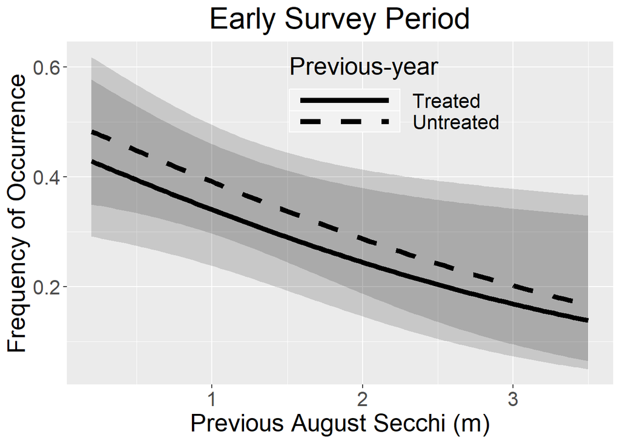

```r
  newdat1<-data.frame(cytrt =rep(0,length(pcri.e$cytrt)),
                      Trte = factor(x = rep(1, length(pcri.e$cytrt)), levels = c(0,1)),
                      Snow = rep(mean(pcri.e$Snow),length(pcri.e$Snow)),
                      PrevAUGSecchi = seq(min(pcri.e$PrevAUGSecchi), max(pcri.e$PrevAUGSecchi), length.out = length(pcri.e$cytrt)),
                      IceCover = rep(mean(pcri.e$IceCover),length(pcri.e$cytrt)),
                      Lake = pcri.e$Lake,
                      obs = pcri.e$obs)
  #fitted values
  phat1<-predict(glme.foc.eu, newdat=newdat1, re.form=NA, type="link")
  newdat1$fitted<-plogis(phat1)

  cpred1.CI <- easyPredCI(glme.foc.eu,newdata = newdat1)
  newdat1$up<-cpred1.CI[,2]
  newdat1$low<-cpred1.CI[,1]
  Trt.pred <- newdat1
  newdat1<-data.frame(cytrt =rep(0,length(pcri.e$cytrt)),
                      Trte = factor(x = rep(0, length(pcri.e$cytrt)), levels = c(0,1)),
                      Snow = rep(mean(pcri.e$Snow),length(pcri.e$Snow)),
                      PrevAUGSecchi = seq(min(pcri.e$PrevAUGSecchi), max(pcri.e$PrevAUGSecchi), length.out = length(pcri.e$cytrt)),
                      IceCover = rep(mean(pcri.e$IceCover),length(pcri.e$cytrt)),
                      Lake = pcri.e$Lake,
                      obs = pcri.e$obs)
  #fitted values
  phat1<-predict(glme.foc.eu, newdat=newdat1, re.form=NA, type="link")
  newdat1$fitted<-plogis(phat1)

  cpred1.CI <- easyPredCI(glme.foc.eu,newdata = newdat1)
  newdat1$up<-cpred1.CI[,2]
  newdat1$low<-cpred1.CI[,1]
  UnTrt.pred <- newdat1

  predtype <- list("Untreated", "Treated")
  pred <- rbindlist(list("Untrt" = UnTrt.pred,"Trt" = Trt.pred), idcol = TRUE)

  secchi_early <- ggplot(pred, aes(PrevAUGSecchi,fitted))+
    geom_line(size = 2, aes(linetype = .id))+
    geom_ribbon(aes(ymin=low, ymax=up, group = .id), color = NA , fill = "black", alpha = .15)+
    ylab("Frequency of Occurrence")+
    xlab("Previous August Secchi (m)")  +
    scale_linetype_manual("Previous-year", values = c("Trt" = "solid", "Untrt" = "dashed" ), labels = c("Treated","Untreated"))+
    theme(text = element_text(size=20), legend.position = c(.60, .85), legend.key.width = unit(1.25, "in"), legend.background = element_blank())+
    ggtitle("Early Survey Period")+
    theme(plot.title = element_text(hjust = 0.5))

  secchi_early
```

```r
  # mean change in foc per meter of secchi
  lm(fitted~PrevAUGSecchi, data = rbind(UnTrt.pred,Trt.pred))
```

```
##
## Call:
## lm(formula = fitted ~ PrevAUGSecchi, data = rbind(UnTrt.pred,
##     Trt.pred))
##
## Coefficients:
##   (Intercept)  PrevAUGSecchi
##       0.45923       -0.09249
```

```r
  #' ON average, the early season freq declines 9.2% for each added meter of
```

Secchi clarity.

```r
  # LATE
  #note that we cut off our predicitons at 3m Secchi because beyond that we don't
  # have enough data to inform about trend/pattern
  #Prev Secchi
  length(pcri.p$cytrt)
```

```
## [1] 145
```

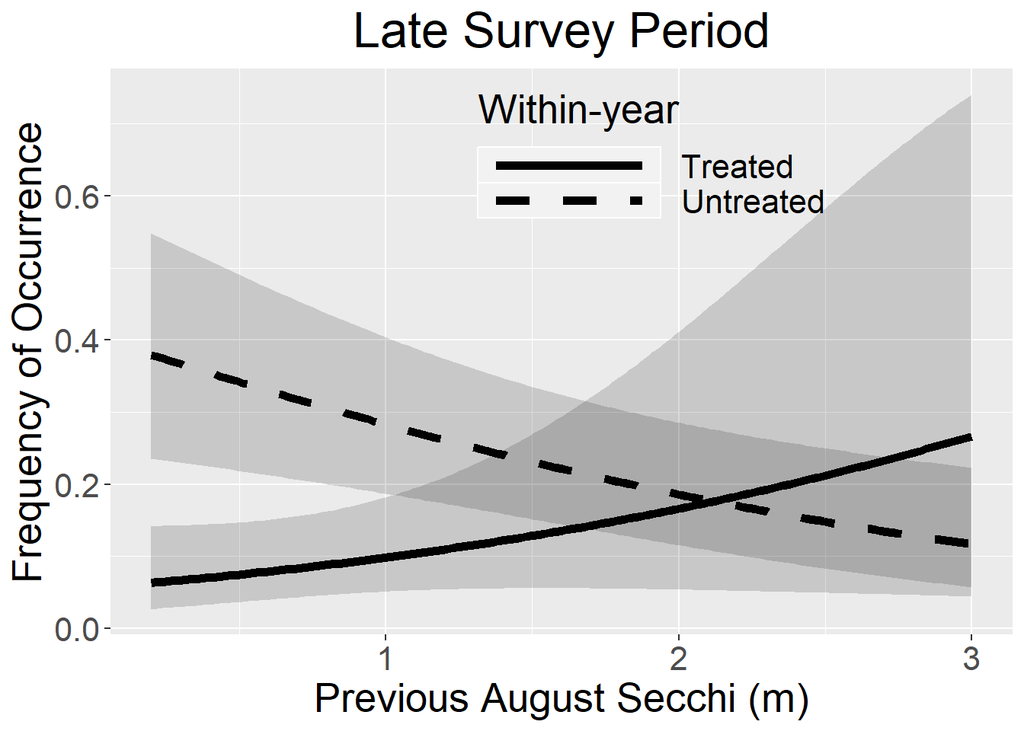

```r
  #trtd
  newdat1<-data.frame(cytrt =rep(0,length(pcri.p$cytrt)),
                      Trt = factor(x = rep(1, length(pcri.p$cytrt)), levels = c(0,1)),
                      Snow = rep(mean(pcri.p$Snow),length(pcri.p$Snow)),
                      PrevAUGSecchi = seq(min(pcri.p$PrevAUGSecchi), 3, length.out = length(pcri.p$cytrt)),
                      IceCover = rep(mean(pcri.p$IceCover),length(pcri.p$cytrt)),
                      Lake = pcri.p$Lake,
                      obs = pcri.p$obs)
  #fitted values
  phat1<-predict(glme.foc.pu2, newdat=newdat1, re.form=NA, type="link")
  newdat1$fitted<-plogis(phat1)

  cpred1.CI <- easyPredCI(glme.foc.pu2,newdata = newdat1)
  newdat1$up<-cpred1.CI[,2]
  newdat1$low<-cpred1.CI[,1]
  Trt.pred <- newdat1
  #untrtd
  newdat1<-data.frame(cytrt =rep(0,length(pcri.p$cytrt)),
                      Trt = factor(x = rep(0, length(pcri.p$cytrt)), levels = c(0,1)),
                      Snow = rep(mean(pcri.p$Snow),length(pcri.p$Snow)),
                      PrevAUGSecchi = seq(min(pcri.p$PrevAUGSecchi), 3, length.out = length(pcri.p$cytrt)),
                      IceCover = rep(mean(pcri.p$IceCover),length(pcri.p$cytrt)),
                      Lake = pcri.p$Lake,
                      obs = pcri.p$obs)
  #fitted values
  phat1<-predict(glme.foc.pu2, newdat=newdat1, re.form=NA, type="link")
  newdat1$fitted<-plogis(phat1)

  cpred1.CI <- easyPredCI(glme.foc.pu2,newdata = newdat1)
  newdat1$up<-cpred1.CI[,2]
  newdat1$low<-cpred1.CI[,1]
  UnTrt.pred <- newdat1

  predtype <- list("Untreated", "Treated")
  pred <- rbindlist(list("Untrt" = UnTrt.pred,"Trt" = Trt.pred), idcol = TRUE)

  secchi_late <- ggplot(pred, aes(PrevAUGSecchi,fitted))+
    geom_line(size = 2, aes(linetype = .id))+
    geom_ribbon(aes(ymin=low, ymax=up, group = .id), color = NA , fill = "black", alpha = .15)+
    ylab("Frequency of Occurrence")+
    xlab("Previous August Secchi (m)")  +
    scale_linetype_manual("Within-year", values = c("Trt" = "solid", "Untrt" = "dashed" ), labels = c("Treated","Untreated"))+
    theme(text = element_text(size=20), legend.position = c(.60, .85), legend.key.width = unit(1.25, "in"), legend.background = element_blank())+
    ggtitle("Late Survey Period")+
    theme(plot.title = element_text(hjust = 0.5))


  secchi_late
```

```r
  # secchi_late+
  # geom_point(aes(x = pcri.p$PrevAUGSecchi, y = pcri.p$foc_clp, shape = pcri.p$Trt ), size = 5, alpha = .4)+
  # geom_line(aes(x = pcri.p$PrevAUGSecchi, y=pcri.p$foc_clp ,group = pcri.p$Lake), alpha = .3)


  # mean change in foc per meter of secchi
  lm(fitted~PrevAUGSecchi, data = rbind(UnTrt.pred,Trt.pred))
```

```
##
## Call:
## lm(formula = fitted ~ PrevAUGSecchi, data = rbind(UnTrt.pred,
##     Trt.pred))
##
## Coefficients:
##   (Intercept)  PrevAUGSecchi
##       0.20586       -0.01113
```

```r
  # secchi_late+
  # geom_point(aes(x = pcri.p$PrevAUGSecchi, y = pcri.p$foc_clp, shape = pcri.p$Trt ), size = 5, alpha = .4)+
  # geom_line(aes(x = pcri.p$PrevAUGSecchi, y=pcri.p$foc_clp ,group = pcri.p$Lake), alpha = .3)


  # mean change in foc per meter of secchi
  lm(fitted~PrevAUGSecchi, data = UnTrt.pred)
```

```
##
## Call:
## lm(formula = fitted ~ PrevAUGSecchi, data = UnTrt.pred)
##
## Coefficients:
##   (Intercept)  PrevAUGSecchi
##       0.38119       -0.09408
```

Again, a 9.4% decline in frequency for each additonal meter of Secchi clarity.

```r
# snow ------------------------------------------------------
```

## Snow

```r
  # EARLY Surveys
  length(pcri.e$cytrt)
```

```
## [1] 101
```

```r
  newdat1<-data.frame(cytrt =rep(0,length(pcri.e$cytrt)),
                      Trte = factor(x = rep(1, length(pcri.e$cytrt)), levels = c(0,1)),
                      Snow = seq(min(pcri.e$Snow), max(pcri.e$Snow), length.out = length(pcri.e$cytrt)),
                      PrevAUGSecchi = rep(mean(pcri.e$PrevAUGSecchi),length(pcri.e$cytrt)),
                      IceCover = rep(mean(pcri.e$IceCover),length(pcri.e$cytrt)),
                      Lake = pcri.e$Lake,
                      obs = pcri.e$obs)
  #fitted values
  phat1<-predict(glme.foc.eu, newdat=newdat1, re.form=NA, type="link")
  newdat1$fitted<-plogis(phat1)

  cpred1.CI <- easyPredCI(glme.foc.eu,newdata = newdat1)
  newdat1$up<-cpred1.CI[,2]
  newdat1$low<-cpred1.CI[,1]
  Trt.pred <- newdat1
  newdat1<-data.frame(cytrt =rep(0,length(pcri.e$cytrt)),
                      Trte = factor(x = rep(0, length(pcri.e$cytrt)), levels = c(0,1)),
                      Snow = seq(min(pcri.e$Snow), max(pcri.e$Snow), length.out = length(pcri.e$cytrt)),
                      PrevAUGSecchi = rep(mean(pcri.e$PrevAUGSecchi),length(pcri.e$cytrt)),
                      IceCover = rep(mean(pcri.e$IceCover),length(pcri.e$cytrt)),
                      Lake = pcri.e$Lake,
                      obs = pcri.e$obs)
  #fitted values
  phat1<-predict(glme.foc.eu, newdat=newdat1, re.form=NA, type="link")
  newdat1$fitted<-plogis(phat1)

  cpred1.CI <- easyPredCI(glme.foc.eu,newdata = newdat1)
  newdat1$up<-cpred1.CI[,2]
  newdat1$low<-cpred1.CI[,1]
  UnTrt.pred <- newdat1

  head(Trt.pred)
```

```
##   cytrt Trte    Snow PrevAUGSecchi IceCover      Lake obs    fitted        up
## 1     0    1 3.81000      1.063366  133.396     belle   1 0.4950654 0.6409608
## 2     0    1 4.76758      1.063366  133.396 blueberry   2 0.4896740 0.6347863
## 3     0    1 5.72516      1.063366  133.396    clearm   3 0.4842849 0.6285921
## 4     0    1 6.68274      1.063366  133.396      coal   4 0.4788995 0.6223812
## 5     0    1 7.64032      1.063366  133.396      coal   5 0.4735190 0.6161564
## 6     0    1 8.59790      1.063366  133.396      coal   6 0.4681447 0.6099208
##         low
## 1 0.3500056
## 2 0.3462813
## 3 0.3425517
## 4 0.3388168
## 5 0.3350768
## 6 0.3313318
```

```r
  tail(Trt.pred)
```

```
##     cytrt Trte     Snow PrevAUGSecchi IceCover   Lake obs    fitted        up
## 96      0    1 94.78010      1.063366  133.396  susan  96 0.1121478 0.2122954
## 97      0    1 95.73768      1.063366  133.396  vails  97 0.1100179 0.2098915
## 98      0    1 96.69526      1.063366  133.396 weaver  98 0.1079235 0.2075160
## 99      0    1 97.65284      1.063366  133.396 weaver  99 0.1058642 0.2051683
## 100     0    1 98.61042      1.063366  133.396 weaver 100 0.1038396 0.2028480
## 101     0    1 99.56800      1.063366  133.396 weaver 101 0.1018494 0.2005547
##            low
## 96  0.05589143
## 97  0.05439579
## 98  0.05293541
## 99  0.05150972
## 100 0.05011814
## 101 0.04876009
```

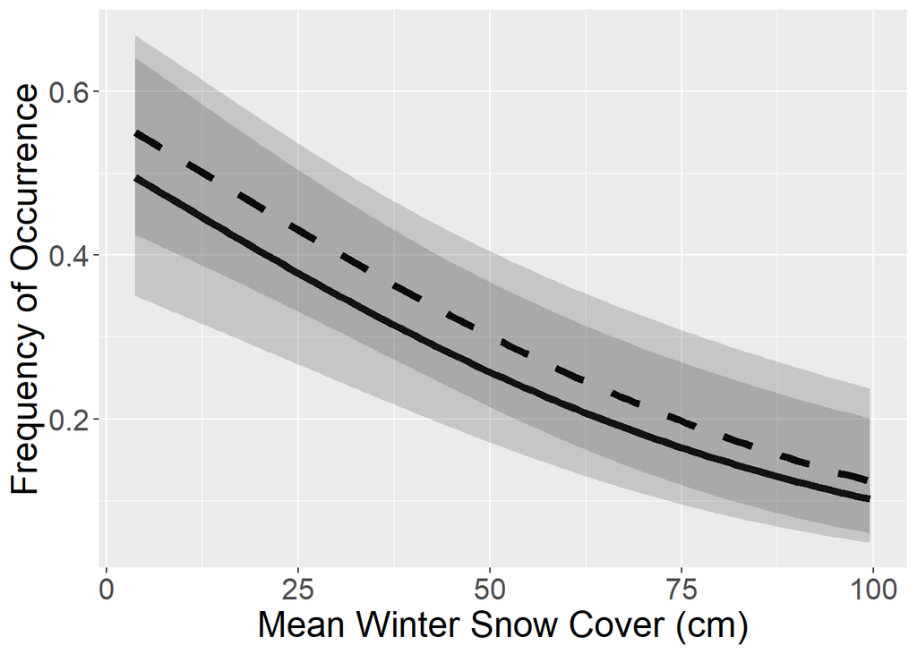

```r
  snow_early <- ggplot(Trt.pred, aes(Snow,fitted))+
    geom_line( size = 2)+
    geom_ribbon(aes(ymin=low, ymax=up), alpha=0.2)+
    geom_line(data = UnTrt.pred,aes(Snow,fitted),  size = 2, linetype = 2)+
    geom_ribbon(data = UnTrt.pred,aes(ymin=low, ymax=up), alpha=0.2)+
    theme(text = element_text(size=20), legend.position = "none")+
    ylab("Frequency of Occurrence")+
    xlab("Mean Winter Snow Cover (cm)")


  snow_early
```

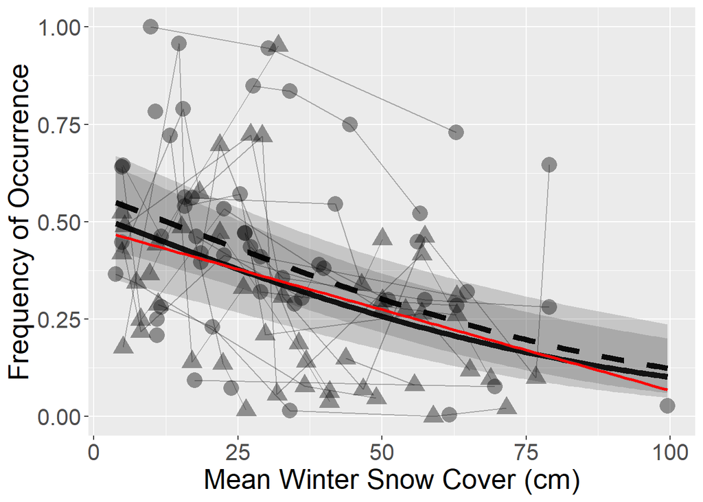

```r
  # show data and average value line
  snow_early+
    geom_line(aes(x = pcri.e$Snow, y=pcri.e$foc_clp ,group = pcri.e$Lake), alpha = .3)+
    geom_point(aes(x = pcri.e$Snow, y = pcri.e$foc_clp, shape = pcri.e$Trte ), size = 5, alpha = .4)+
    geom_smooth( method = "lm", color = "red")
```

```r
  # mean change in foc per centimeter of snow
  bound <- bind_rows(UnTrt.pred,Trt.pred)
  lm(fitted~Snow, data = bound)
```

```
##
## Call:
## lm(formula = fitted ~ Snow, data = bound)
##
## Coefficients:
## (Intercept)         Snow
##    0.512700    -0.004345
```

```r
  lm(fitted~Snow, data = bound)$'coefficients'[2]*2.54 #convert to inches
```

```
##        Snow
## -0.01103517
```

```r
  #' This comes out to approximately a 1.1% change in foc per addt'l inch of snow

  #LATE Surveys
  length(pcri.p$cytrt)
```

```
## [1] 145
```

```r
  newdat1<-data.frame(cytrt =rep(0,length(pcri.p$cytrt)),
                      Trt = factor(x = rep(1, length(pcri.p$cytrt)), levels = c(0,1)),
                      Snow = seq(min(pcri.p$Snow), max(pcri.p$Snow), length.out = length(pcri.p$cytrt)),
                      PrevAUGSecchi = rep(mean(pcri.p$PrevAUGSecchi),length(pcri.p$cytrt)),
                      IceCover = rep(mean(pcri.p$IceCover),length(pcri.p$cytrt)),
                      Lake = pcri.p$Lake,
                      obs = pcri.p$obs)
  #fitted values
  phat1<-predict(glme.foc.pu2, newdat=newdat1, re.form=NA, type="link")
  newdat1$fitted<-plogis(phat1)

  cpred1.CI <- easyPredCI(glme.foc.pu2,newdata = newdat1)
  newdat1$up<-cpred1.CI[,2]
  newdat1$low<-cpred1.CI[,1]
  Trt.pred <- newdat1
  newdat1<-data.frame(cytrt =rep(0,length(pcri.p$cytrt)),
                      Trt = factor(x = rep(0, length(pcri.p$cytrt)), levels = c(0,1)),
                      Snow = seq(min(pcri.p$Snow), max(pcri.p$Snow), length.out = length(pcri.p$cytrt)),
                      PrevAUGSecchi = rep(mean(pcri.p$PrevAUGSecchi),length(pcri.p$cytrt)),
                      IceCover = rep(mean(pcri.p$IceCover),length(pcri.p$cytrt)),
                      Lake = pcri.p$Lake,
                      obs = pcri.p$obs)
  #fitted values
  phat1<-predict(glme.foc.pu2, newdat=newdat1, re.form=NA, type="link")
  newdat1$fitted<-plogis(phat1)

  cpred1.CI <- easyPredCI(glme.foc.pu2,newdata = newdat1)
  newdat1$up<-cpred1.CI[,2]
  newdat1$low<-cpred1.CI[,1]
  UnTrt.pred <- newdat1

  head(Trt.pred)
```

```
##   cytrt Trt     Snow PrevAUGSecchi IceCover     Lake obs     fitted        up
## 1     0   1 2.794000      1.181379      134 reshanau   1 0.04957300 0.1090345
## 2     0   1 3.402542      1.181379      134 reshanau   2 0.05030841 0.1099688
## 3     0   1 4.011083      1.181379      134 reshanau   3 0.05105415 0.1109221
## 4     0   1 4.619625      1.181379      134 reshanau   4 0.05181034 0.1118949
## 5     0   1 5.228167      1.181379      134 reshanau   5 0.05257711 0.1128879
## 6     0   1 5.836708      1.181379      134 reshanau   6 0.05335458 0.1139016
##          low
## 1 0.02174709
## 2 0.02220745
## 3 0.02267463
## 4 0.02314860
## 5 0.02362933
## 6 0.02411674
```

```r
  tail(Trt.pred)
```

```
##     cytrt Trt     Snow PrevAUGSecchi IceCover    Lake obs    fitted        up
## 140     0   1 87.38129      1.181379      134  clearw 140 0.3102490 0.6460522
## 141     0   1 87.98983      1.181379      134  clearw 141 0.3135756 0.6518601
## 142     0   1 88.59838      1.181379      134  clearw 142 0.3169215 0.6576291
## 143     0   1 89.20692      1.181379      134  clearw 143 0.3202865 0.6633577
## 144     0   1 89.81546      1.181379      134 stjames 144 0.3236703 0.6690442
## 145     0   1 90.42400      1.181379      134 stjames 145 0.3270726 0.6746872
##            low
## 140 0.09978262
## 141 0.10027825
## 142 0.10077367
## 143 0.10126893
## 144 0.10176403
## 145 0.10225902
```

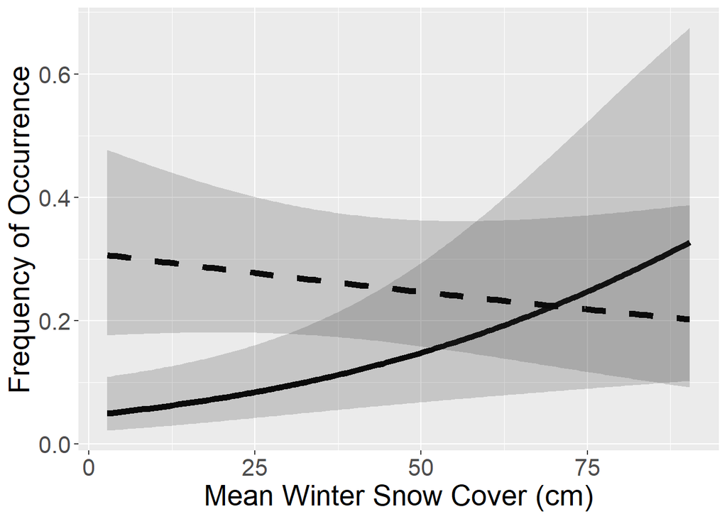

```r
  snow_late <- ggplot(Trt.pred, aes(Snow,fitted))+
    geom_line(size = 2)+
    geom_ribbon(aes(ymin=low, ymax=up), alpha=0.2)+
    geom_line(data = UnTrt.pred,aes(Snow,fitted), size = 2, linetype = 2)+
    geom_ribbon(data = UnTrt.pred,aes(ymin=low, ymax=up), alpha=0.2)+
    theme(text = element_text(size=20), legend.position = "none")+
    ylab("Frequency of Occurrence")+
    xlab("Mean Winter Snow Cover (cm)")
  snow_late
```

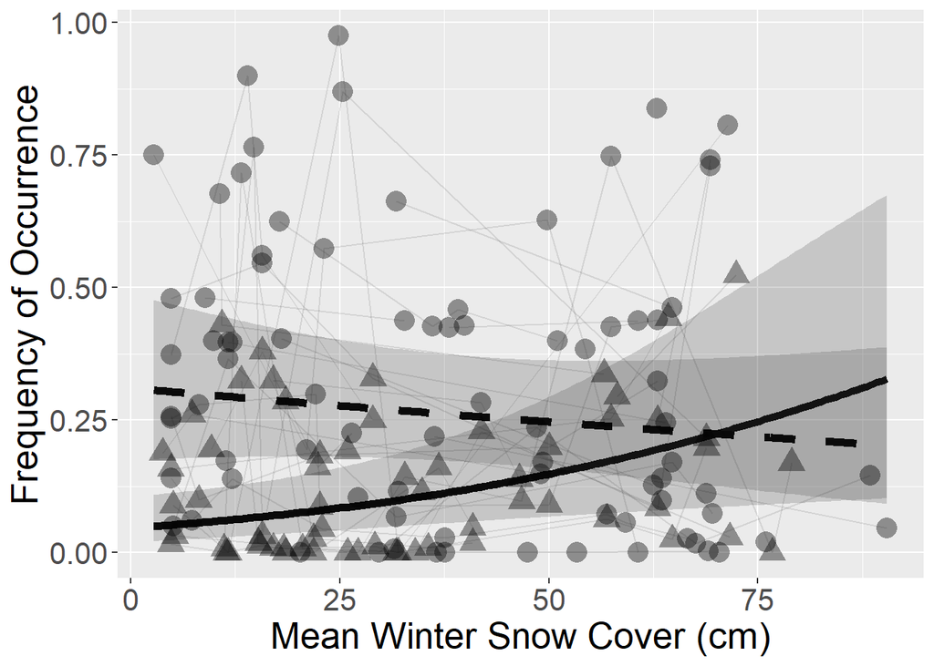

```r
  # uncomment these lines to add data in background:
  snow_late+
  geom_point(aes(x = pcri.p$Snow, y = pcri.p$foc_clp, shape = pcri.p$Trt ), size = 5, alpha = .4)+
    geom_line(aes(x = pcri.p$Snow, y=pcri.p$foc_clp ,group = pcri.p$Lake), alpha = .1)
```

```r
  # mean change in foc per inch of snow
  bound <- bind_rows(Trt.pred)
  lm(fitted~Snow, data = bound)
```

```
##
## Call:
## lm(formula = fitted ~ Snow, data = bound)
##
## Coefficients:
## (Intercept)         Snow
##    0.009798     0.003114
```

```r
  lm(fitted~Snow, data = bound)$'coefficients'[2]*2.54 #convert to inches
```

```
##       Snow
## 0.00790883
```

```r
  # summary(trt.snow.pred)
```

```r
# ice -------------------------------------------------------
```

## Ice

```r
  # Early Surveys
  length(pcri.e$cytrt)
```

```
## [1] 101
```

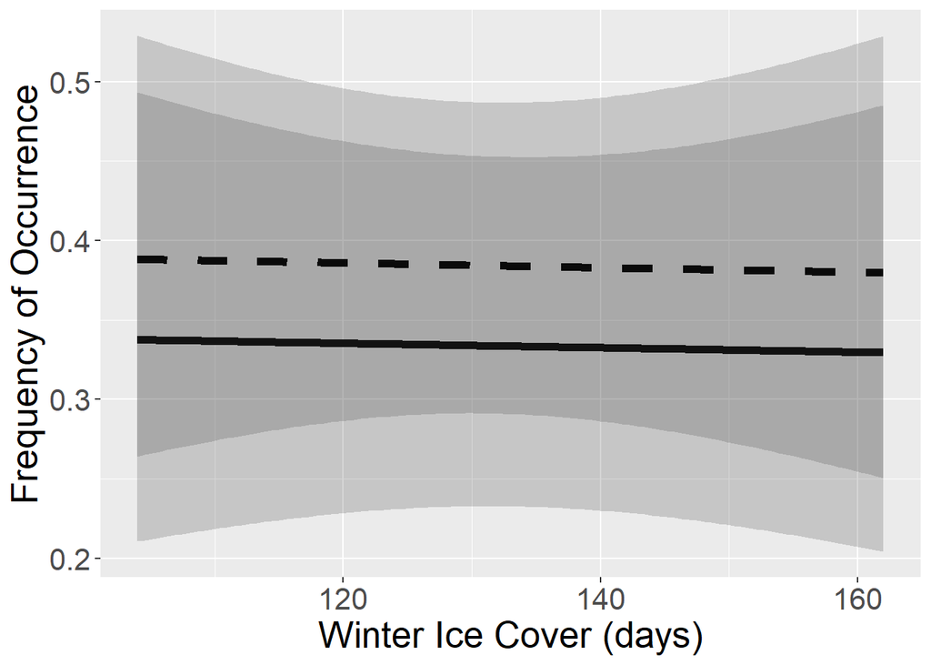

```r
  newdat1<-data.frame(cytrt =rep(0,length(pcri.e$cytrt)),
                      Trte = factor(x = rep(1, length(pcri.e$cytrt)), levels = c(0,1)),
                      Snow = rep(mean(pcri.e$Snow),length(pcri.e$Snow)),
                      PrevAUGSecchi = rep(mean(pcri.e$PrevAUGSecchi),length(pcri.e$cytrt)),
                      IceCover = seq(min(pcri.e$IceCover), max(pcri.e$IceCover), length.out = length(pcri.e$cytrt)),
                      Lake = pcri.e$Lake,
                      obs = pcri.e$obs)
  #fitted values
  phat1<-predict(glme.foc.eu, newdat=newdat1, re.form=NA, type="link")
  newdat1$fitted<-plogis(phat1)

  cpred1.CI <- easyPredCI(glme.foc.eu,newdata = newdat1)
  newdat1$up<-cpred1.CI[,2]
  newdat1$low<-cpred1.CI[,1]
  Trt.pred <- newdat1
  newdat1<-data.frame(cytrt =rep(0,length(pcri.e$cytrt)),
                      Trte = factor(x = rep(0, length(pcri.e$cytrt)), levels = c(0,1)),
                      Snow = rep(mean(pcri.e$Snow),length(pcri.e$Snow)),
                      PrevAUGSecchi = rep(mean(pcri.e$PrevAUGSecchi),length(pcri.e$cytrt)),
                      IceCover = seq(min(pcri.e$IceCover), max(pcri.e$IceCover), length.out = length(pcri.e$cytrt)),
                      obs = pcri.e$obs)
  #fitted values
  phat1<-predict(glme.foc.eu, newdat=newdat1, re.form=NA, type="link")
  newdat1$fitted<-plogis(phat1)

  cpred1.CI <- easyPredCI(glme.foc.eu,newdata = newdat1)
  newdat1$up<-cpred1.CI[,2]
  newdat1$low<-cpred1.CI[,1]
  UnTrt.pred <- newdat1

  ice_early <- ggplot(Trt.pred, aes(IceCover,fitted))+
    geom_line( size = 2)+
    geom_ribbon(aes(ymin=low, ymax=up), alpha=0.2)+
    geom_line(data = UnTrt.pred,aes(IceCover, fitted), size = 2, linetype = 2)+
    geom_ribbon(data = UnTrt.pred,aes(ymin=low, ymax=up), alpha=0.2)+
    theme(text = element_text(size=20), legend.position = "none")+
    ylab("Frequency of Occurrence")+
    xlab("Winter Ice Cover (days)")  +
    scale_color_manual(breaks = c(0,1), values = c("blue", "red"))
  ice_early
```

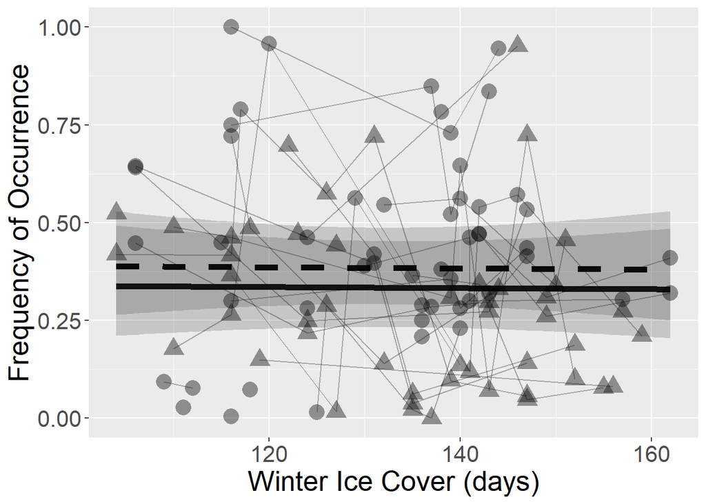

```r
  # plots data in background:
    ice_early+
      geom_point(aes(x = pcri.e$IceCover, y = pcri.e$foc_clp, shape = pcri.e$Trte ), size = 5, alpha = .4)+
      geom_line(aes(x = pcri.e$IceCover, y=pcri.e$foc_clp ,group = pcri.e$Lake), alpha = .3)
```

```r
  # Late Surveys
  length(pcri.p$cytrt)
```

```
## [1] 145
```

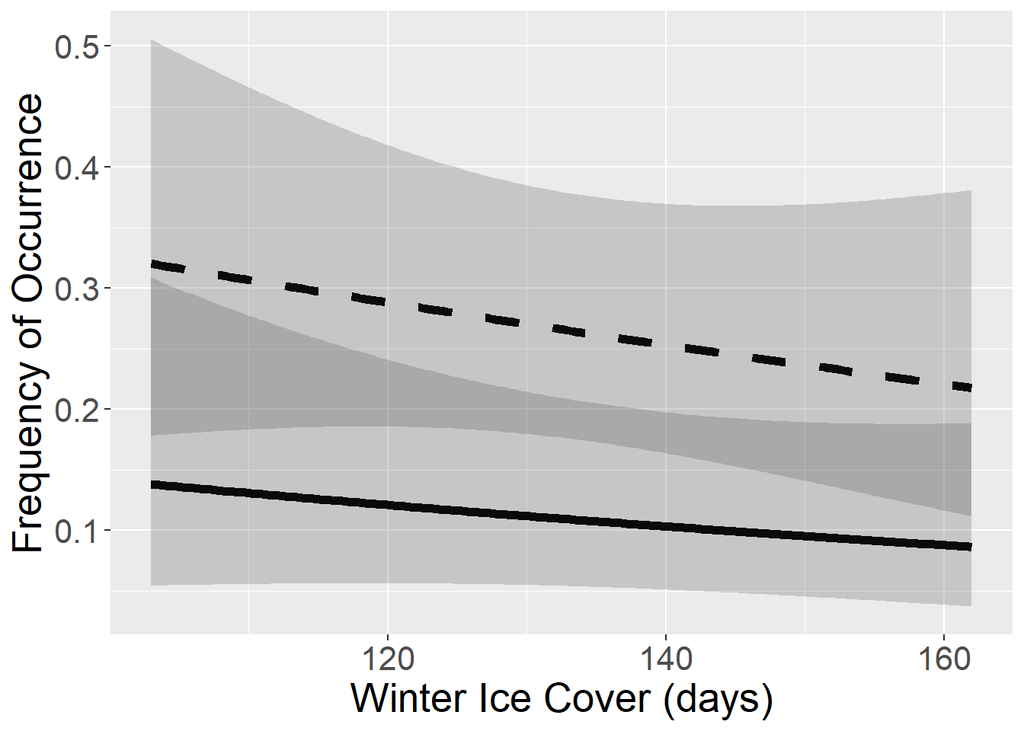

```r
  newdat1<-data.frame(cytrt =rep(0,length(pcri.p$cytrt)),
                      Trt = factor(x = rep(1, length(pcri.p$cytrt)), levels = c(0,1)),
                      Snow = rep(mean(pcri.p$Snow),length(pcri.p$Snow)),
                      PrevAUGSecchi = rep(mean(pcri.p$PrevAUGSecchi),length(pcri.p$cytrt)),
                      IceCover = seq(min(pcri.p$IceCover), max(pcri.p$IceCover), length.out = length(pcri.p$cytrt)),
                      Lake = pcri.p$Lake,
                      obs = pcri.p$obs)
  #fitted values
  phat1<-predict(glme.foc.pu2, newdat=newdat1, re.form=NA, type="link")
  newdat1$fitted<-plogis(phat1)

  cpred1.CI <- easyPredCI(glme.foc.pu2,newdata = newdat1)
  newdat1$up<-cpred1.CI[,2]
  newdat1$low<-cpred1.CI[,1]
  Trt.pred <- newdat1
  newdat1<-data.frame(cytrt =rep(0,length(pcri.p$cytrt)),
                      Trt = factor(x = rep(0, length(pcri.p$cytrt)), levels = c(0,1)),
                      Snow = rep(mean(pcri.p$Snow),length(pcri.p$Snow)),
                      PrevAUGSecchi = rep(mean(pcri.p$PrevAUGSecchi),length(pcri.p$cytrt)),
                      IceCover = seq(min(pcri.p$IceCover), max(pcri.p$IceCover), length.out = length(pcri.p$cytrt)),
                      Lake = pcri.p$Lake,
                      obs = pcri.p$obs)
  #fitted values
  phat1<-predict(glme.foc.pu2, newdat=newdat1, re.form=NA, type="link")
  newdat1$fitted<-plogis(phat1)

  cpred1.CI <- easyPredCI(glme.foc.pu2,newdata = newdat1)
  newdat1$up<-cpred1.CI[,2]
  newdat1$low<-cpred1.CI[,1]
  UnTrt.pred <- newdat1

  ice_late <- ggplot(Trt.pred, aes(IceCover,fitted))+
    geom_line(size = 2)+
    geom_ribbon(aes(ymin=low, ymax=up), alpha=0.2)+
    geom_line(data = UnTrt.pred,aes(IceCover, fitted),size = 2, linetype = 2 )+
    geom_ribbon(data = UnTrt.pred,aes(ymin=low, ymax=up), alpha=0.2)+
    theme(text = element_text(size=20), legend.position = "none")+
    ylab("Frequency of Occurrence")+
    xlab("Winter Ice Cover (days)")
  ice_late
```

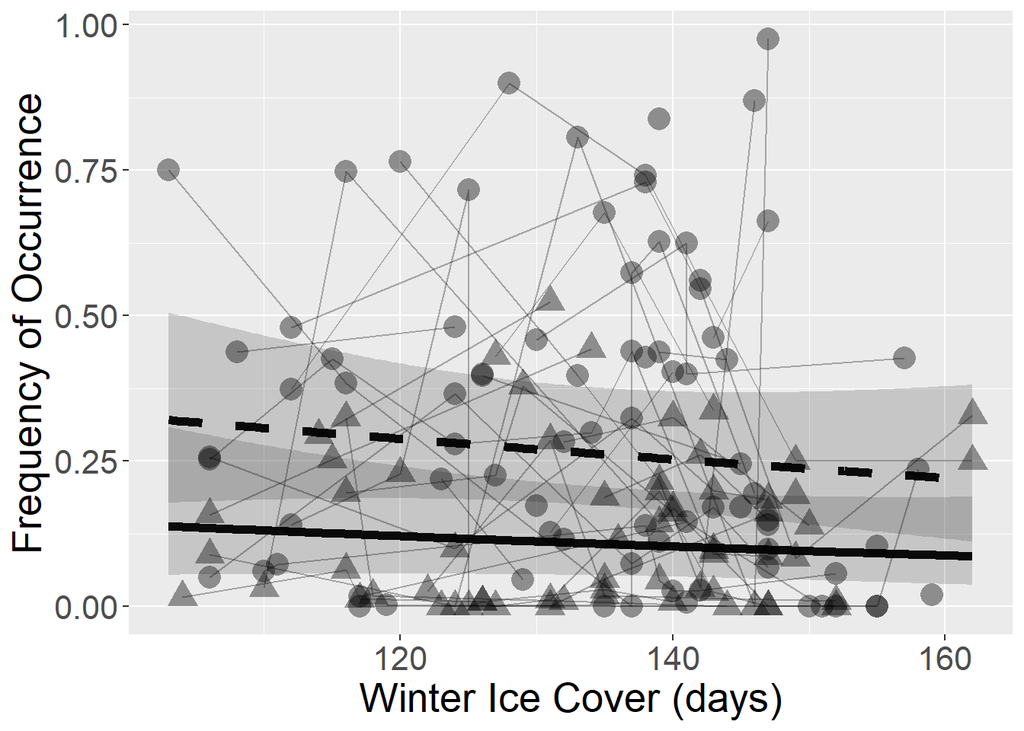

```r
  ice_late+
    geom_point(aes(x = pcri.p$IceCover, y = pcri.p$foc_clp, shape = pcri.p$Trt ), size = 5, alpha = .4)+
    geom_line(aes(x = pcri.p$IceCover, y=pcri.p$foc_clp ,group = pcri.p$Lake), alpha = .3)+
    scale_color_manual(breaks = c(0,1), values = c("blue", "red"))
```

these are much nicer, but they do not explain how the effect that is observed is after accounting for other drivers (background data are “raw”)

```r
# cytrt -------------------------------------------------------------------
```

## Consecutive Years of Treatment

```r
  # EARLY Surveys
  length(pcri.e$cytrt)
```

```
## [1] 101
```

```r
  newdat1<-data.frame(cytrt = seq(min(pcri.e$cytrt),
                                  max(pcri.e$cytrt),  length.out = length(pcri.e$cytrt)),
                      Trte = factor(x = rep(1, length(pcri.e$cytrt)), levels = c(0,1)),
                      Snow = rep(mean(pcri.e$Snow),length(pcri.e$cytrt)),
                      PrevAUGSecchi = rep(mean(pcri.e$PrevAUGSecchi),length(pcri.e$cytrt)),
                      IceCover = rep(mean(pcri.e$IceCover),length(pcri.e$cytrt)),
                      Lake = pcri.e$Lake,
                      obs = pcri.e$obs)
  #fitted values
  phat1<-predict(glme.foc.eu, newdat=newdat1, re.form=NA, type="link")
  newdat1$fitted<-plogis(phat1)

  cpred1.CI <- easyPredCI(glme.foc.eu,newdata = newdat1) # see fn documentation in load fns section
  newdat1$up<-cpred1.CI[,2]
  newdat1$low<-cpred1.CI[,1]
  Trt.pred <- newdat1
```

The line we’ll show is smoothed, but here are the declines for each added, consecutive year of treatment:

```r
  Trt.pred[Trt.pred$cytrt == 0,"fitted"] - Trt.pred[Trt.pred$cytrt == 1,"fitted"] # This means going from a single year of treating to two years (1 addt'l consecutive year)
```

```
## [1] 0.1059016
```

```r
  Trt.pred[Trt.pred$cytrt == 1,"fitted"] - Trt.pred[Trt.pred$cytrt == 2,"fitted"]
```

```
## [1] 0.07974466
```

```r
  Trt.pred[Trt.pred$cytrt == 2,"fitted"] - Trt.pred[Trt.pred$cytrt == 3,"fitted"]
```

```
## [1] 0.05516925
```

```r
  Trt.pred[Trt.pred$cytrt == 3,"fitted"] - Trt.pred[Trt.pred$cytrt == 4,"fitted"]
```

```
## [1] 0.03596682
```

```r
  Trt.pred[Trt.pred$cytrt == 4,"fitted"] - Trt.pred[Trt.pred$cytrt == 5,"fitted"]
```

```
## [1] 0.02254865
```

If we strike a line through the model we find mean change in freq per additonal year of treatment.

```r
  bound <- bind_rows(Trt.pred)
  lm(fitted~cytrt, data = bound)
```

```
##
## Call:
## lm(formula = fitted ~ cytrt, data = bound)
##
## Coefficients:
## (Intercept)        cytrt
##     0.28591     -0.05813
```

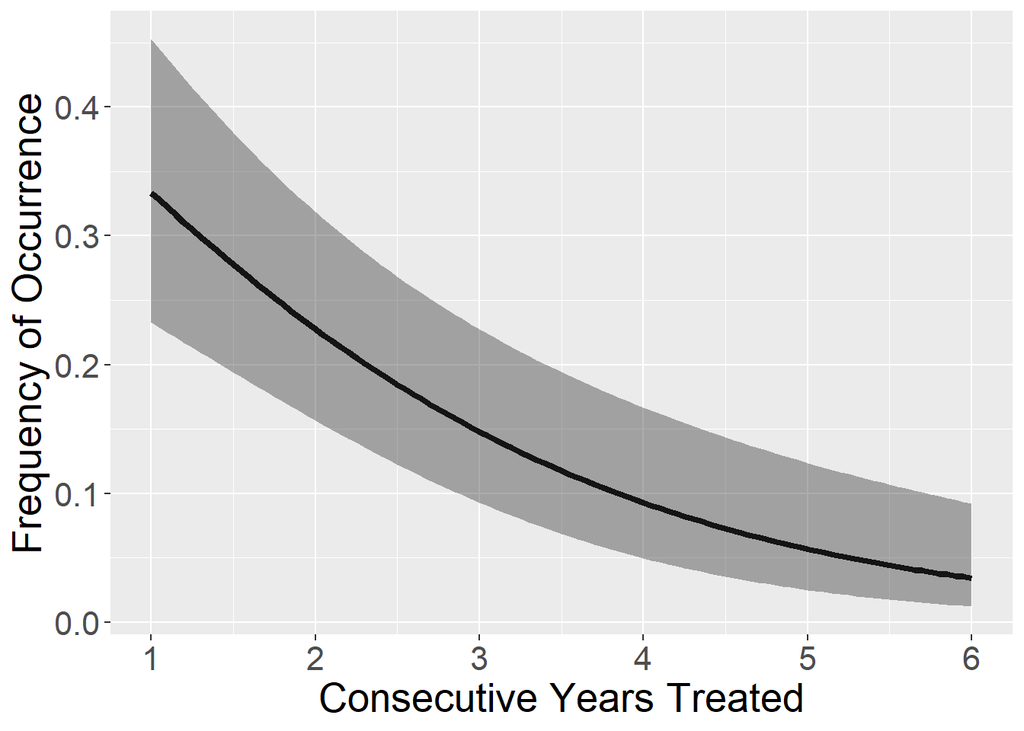

```r
  # note that I have shifted the axis labels so that the first year of trt is not zero
cytrt_early <-   ggplot(Trt.pred, aes(cytrt,fitted))+
    geom_line(size = 1.5)+
    geom_ribbon(aes(ymin=low, ymax=up), alpha=0.4)+
    theme(text = element_text(size=20), legend.position = "none")+
    ylab("Frequency of Occurrence")+
    xlab("Consecutive Years Treated")  +
    scale_x_continuous( breaks = seq(0,5, by = 1),
                        labels = seq(1,6, by = 1),
                        limits = c(0,5))
  cytrt_early
```

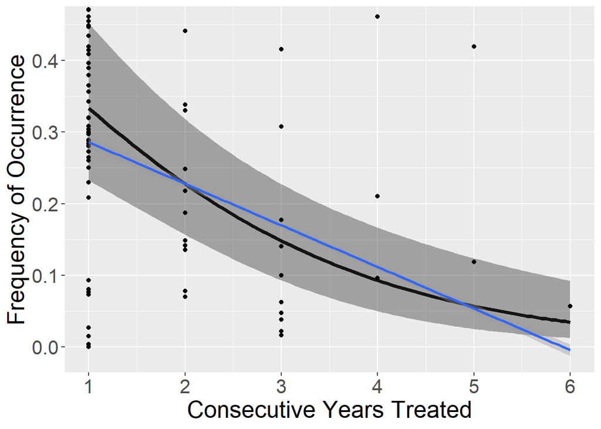

```r
  # plot data in backgroud
cytrt_early +
    geom_point(x = pcri.e$cytrt, y = pcri.e$foc_clp)+
    geom_smooth(method = "lm")
```

```r
  # LATE Surveys
  length(pcri.p$cytrt)
```

```
## [1] 145
```

```r
  newdat1<-data.frame(cytrt = seq(min(pcri.p$cytrt),
                                  max(pcri.p$cytrt),  length.out = length(pcri.p$cytrt)),
                      Trt = factor(x = rep(1, length(pcri.p$cytrt)), levels = c(0,1)),
                      Snow = rep(mean(pcri.p$Snow),length(pcri.p$cytrt)),
                      PrevAUGSecchi = rep(mean(pcri.p$PrevAUGSecchi),length(pcri.p$cytrt)),
                      IceCover = rep(mean(pcri.p$IceCover),length(pcri.p$cytrt)),
                      Lake = pcri.p$Lake,
                      obs = pcri.p$obs)
  #fitted values
  phat1<-predict(glme.foc.pu2, newdat=newdat1, re.form=NA, type="link")
  newdat1$fitted<-plogis(phat1)

  cpred1.CI <- easyPredCI(glme.foc.pu2,newdata = newdat1)
  newdat1$up<-cpred1.CI[,2]
  newdat1$low<-cpred1.CI[,1]
  Trt.pred <- newdat1

  # declines for each added, consecutive year of treatment:
  Trt.pred[Trt.pred$cytrt == 0,"fitted"] - Trt.pred[Trt.pred$cytrt == 1,"fitted"] # This means going from a single year of treating to two years (1 addt'l consecutive year)
```

```
## [1] 0.0258115
```

```r
  Trt.pred[Trt.pred$cytrt == 1,"fitted"] - Trt.pred[Trt.pred$cytrt == 2,"fitted"]
```

```
## [1] 0.020102
```

```r
  Trt.pred[Trt.pred$cytrt == 2,"fitted"] - Trt.pred[Trt.pred$cytrt == 3,"fitted"]
```

```
## [1] 0.01546596
```

```r
  Trt.pred[Trt.pred$cytrt == 3,"fitted"] - Trt.pred[Trt.pred$cytrt == 4,"fitted"]
```

```
## [1] 0.01178798
```

```r
  Trt.pred[Trt.pred$cytrt == 4,"fitted"] - Trt.pred[Trt.pred$cytrt == 5,"fitted"]
```

```
## [1] 0.008920582
```

```r
  Trt.pred[Trt.pred$cytrt == 5,"fitted"] - Trt.pred[Trt.pred$cytrt == 6,"fitted"]
```

```
## [1] 0.006714163
```

```r
  Trt.pred[Trt.pred$cytrt == 6,"fitted"] - Trt.pred[Trt.pred$cytrt == 7,"fitted"]
```

```
## [1] 0.005032884
```

```r
  Trt.pred[Trt.pred$cytrt == 7,"fitted"] - Trt.pred[Trt.pred$cytrt == 8,"fitted"]
```

```
## [1] 0.003761074
```

```r
  # avg change per year modeled
  bound <- bind_rows(Trt.pred)
  lm(fitted~cytrt, data = bound)
```

```
##
## Call:
## lm(formula = fitted ~ cytrt, data = bound)
##
## Coefficients:
## (Intercept)        cytrt
##     0.08908     -0.01143
```

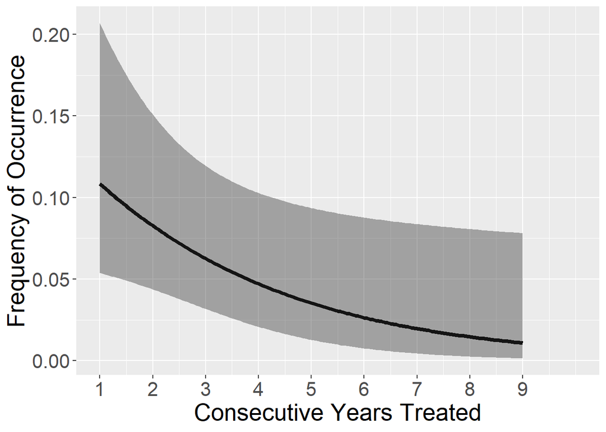

```r
  cytrt_late <- ggplot(Trt.pred, aes(cytrt,fitted))+
    geom_line( size = 1.5)+
    geom_ribbon(aes(ymin=low, ymax=up), alpha=0.4)+
    theme(text = element_text(size=20), legend.position = "none")+
    ylab("Frequency of Occurrence")+
    xlab("Consecutive Years Treated")  +
    scale_x_continuous( breaks = seq(0,8, by = 1),
                        labels = seq(1,9, by = 1),
                        limits = c(0,9))
  cytrt_late
```

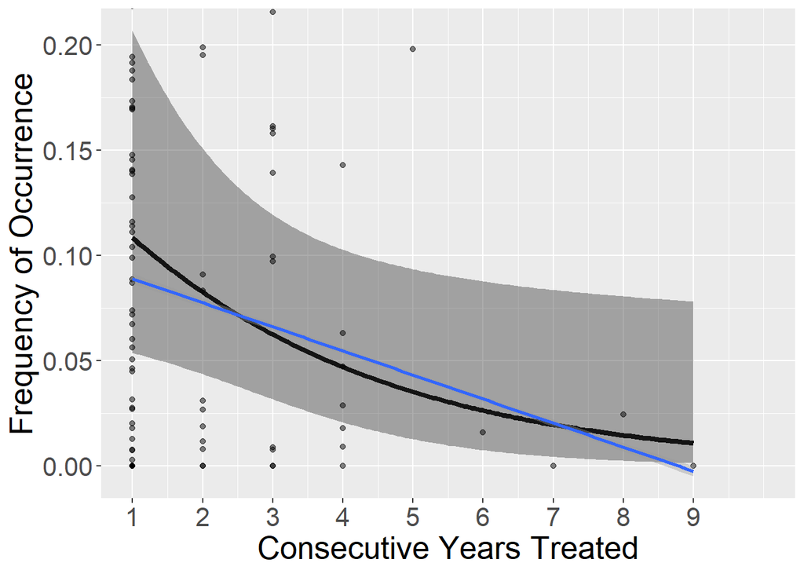

```r
  # mean change in foc per yr trt
cytrt_late+
    geom_point(x = pcri.p$cytrt, y = pcri.p$foc_clp, alpha = .5)+
    geom_smooth(method = "lm")
```

```r
# treatment effects -------------------------------------------------------
```